# vaccine-distribution

Anthony Morada

1/13/2021

# 1 Getting and Cleaning Data

```r
knitr::opts_chunk$set(
    echo = TRUE,
    message = TRUE,
    warning = TRUE
)

library(dplyr)
library(janitor)
```

```r
library(tableone)
library(finalfit)
library(ggplot2)

#For TableOne
kableone <- function(x, ...) {
  capture.output(x <- print(x))
  knitr::kable(x, ...)
}

#Chunk timing
knitr::knit_hooks$set(time_it = local({
  now <- NULL
  function(before, options) {
    if (before) {
      # record the current time before each chunk
      now <<- Sys.time()
    } else {
      # calculate the time difference after a chunk
      res <- difftime(Sys.time(), now, units = "hours")
      # return a character string to show the time
      paste("Time for the chunk", options$label, "to run:", res, "hours")
    }
  }
}))

knitr::opts_chunk$set(time_it = TRUE)
```

```r
df <- read.csv("~/Dropbox/My Mac (MacBook-Pro.hsd1.pa.comcast.net)/Documents/GitHub/covid_case_restricted_detailed/data/COVID_Cases_Restricted_Detailed_12312020_Part_1.csv")

temp <- read.csv("~/Dropbox/My Mac (MacBook-Pro.hsd1.pa.comcast.net)/Documents/GitHub/covid_case_restricted_detailed/data/COVID_Cases_Restricted_Detailed_12312020_Part_2.csv/COVID_Cases_Restricted_Detailed_12312020_Part_2.csv", header=FALSE)

colnames(temp) <- colnames(df)

df <- rbind(df,temp)

rm(temp)
```

Time for the chunk LOAD DATA to run: 0.0358907878398895 hours

```r
# Replacing "Missing"
df<- as.data.frame(lapply(df, function(y) gsub("Missing", NA, y)))

#Formatting date columns
df <- df %>%
  mutate(cdc_report_dt=as.Date.character(cdc_report_dt, format="%Y-%m-%d")) %>%
  mutate(onset_dt=as.Date.character(onset_dt, format="%Y-%m-%d")) %>%
  mutate(pos_spec_dt=as.Date.character(pos_spec_dt, format="%Y-%m-%d")) %>%
  mutate(cdc_case_earliest_dt=as.Date.character(cdc_case_earliest_dt, format="%Y-%m-%d"))

#Selecting for only laboratory confirmed cases
df <- df[df$current_status=="Laboratory-confirmed case",]

#Selecting for positive specimen date < 2020-12-15
df <- df[df$pos_spec_dt < "2020-12-15" & !is.na(df$pos_spec_dt),]

#Cleaning sex
df$sex <- as.factor(df$sex)
levels(df$sex) <- list(
  "Male" = "Male",
  "Female" = "Female",
  "Other or Unknown" = c("Other", "Unknown")
)

#Creating Region Variable
df$res_region <- as.factor(df$res_state)
levels(df$res_region) <- list(
  "Northeast" = c("CT", "ME", "MA", "NH", "RI", "VT", "NJ", "NY", "NYC", "PA"),
  "Midwest" = c("IN", "IL", "MI", "OH", "WI", "IA", "KS", "MN", "MO", "NE", "ND","SD"),
  "South" = c("DE", "DC", "FL", "GA", "MD", "NC", "SC", "VA", "WV", "AL", "KY", "MS", "TN", "AR", "LA", "OK", "TX"),
  "Pacific"= c("AZ", "CO", "ID", "NM", "MT", "UT", "NV", "WY", "AK", "CA", "HI", "OR", "WA"),
  "US Territory or Unknown" = c("GU", "MP", "OCONUS", "PR", "Unknown", "VI")
  )
```

Time for the chunk CLEAN to run: 0.119609425531493 hours

# 2 Exploratory Data Analysis

```r
# independent variables
ind_vars <- c("sex", "age_group", "race_ethnicity_combined", "res_region", "hc_work_yn", "medcond_yn")
# dependent variables
dep_vars <- c("hosp_yn", "icu_yn", "mechvent_yn", "pna_yn", "acuterespdistress_yn", "death_yn")

# Additional Cleaning: all outcome data (dependent variables) will having "unknown" replaced with NA
df[dep_vars] <- lapply(df[dep_vars], gsub, pattern = "Unknown", replacement = NA)

###Converting Character Columns into factors prior to analysis
df[sapply(df, is.character)] <- lapply(df[sapply(df, is.character)], as.factor)

# ALL USED VARIABLES
vars <- c(ind_vars, dep_vars)

#Adjusting Levels in Factors
df$age_group <- relevel(df$age_group, "10 - 19 Years")
df$race_ethnicity_combined <- relevel(df$race_ethnicity_combined, "White, Non-Hispanic")
df$res_region <- relevel(df$res_region, "Northeast")
```

Time for the chunk CATEGORIZING VARIABLES to run: 0.00416554305288527 hours

- Independent Variables include: sex, age_group, race_ethnicity_combined, res_region, hc_work_yn, medcond_yn.
- Dependent Variables include: hosp_yn, icu_yn, mechvent_yn, pna_yn, acuterespdistress_yn, death_yn.

## 2.1 Data Exploration of Independent and Dependent Variables

```r
#independent vars table
print("Summary of Independent Variables")
```

```
## [1] "Summary of Independent Variables"
```

```r
kableone(print(
  CreateTableOne(vars = ind_vars, data = df),
  showAllLevels = TRUE,
  missing = TRUE,
  noSpaces = TRUE
  ))
```

|  | level | Overall | Missing |
| --- | --- | --- | --- |
| n |  | 3798261 |  |
| sex (%) | Male | 1795160 (47.6) | 0.8 |
|  | Female | 1954915 (51.9) |  |
|  | Other or Unknown | 18709 (0.5) |  |
| age_group (%) | 10 - 19 Years | 379438 (10.0) | 0.3 |
|  | 0 - 9 Years | 141591 (3.7) |  |
|  | 20 - 29 Years | 711770 (18.8) |  |
|  | 30 - 39 Years | 611965 (16.2) |  |
|  | 40 - 49 Years | 562714 (14.9) |  |
|  | 50 - 59 Years | 555063 (14.7) |  |
|  | 60 - 69 Years | 403679 (10.7) |  |
|  | 70 - 79 Years | 231412 (6.1) |  |
|  | 80+ Years | 185817 (4.9) |  |
|  | Unknown | 2038 (0.1) |  |
| race_ethnicity_combined (%) | White, Non-Hispanic | 1324461 (36.9) | 5.4 |
|  | American Indian/Alaska Native, Non-Hispanic | 15431 (0.4) |  |
|  | Asian, Non-Hispanic | 67567 (1.9) |  |
|  | Black, Non-Hispanic | 288992 (8.0) |  |
|  | Hispanic/Latino | 489383 (13.6) |  |
|  | Multiple/Other, Non-Hispanic | 111481 (3.1) |  |
|  | Native Hawaiian/Other Pacific Islander, Non-Hispanic | 11060 (0.3) |  |
|  | Unknown | 1284121 (35.7) |  |
| res_region (%) | Northeast | 1325064 (34.9) | 0.0 |
|  | Midwest | 745419 (19.6) |  |
|  | South | 1050551 (27.7) |  |
|  | Pacific | 669141 (17.6) |  |
|  | US Territory or Unknown | 7282 (0.2) |  |
| hc_work_yn (%) | No | 1255055 (56.4) | 41.4 |
|  | Unknown | 839629 (37.7) |  |
|  | Yes | 130446 (5.9) |  |
| medcond_yn (%) | No | 711859 (30.3) | 38.2 |
|  | Unknown | 1002138 (42.7) |  |
|  | Yes | 633792 (27.0) |  |

```r
#dependent vars
print("Summary of Dependent Variables")
```

```
## [1] "Summary of Dependent Variables"
```

```r
kableone(print(
  CreateTableOne(vars = dep_vars, data = df),
  showAllLevels = TRUE,
  missing = TRUE,
  noSpaces = TRUE
  ))
```

|  | level | Overall | Missing |
| --- | --- | --- | --- |
| n |  | 3798261 |  |
| hosp_yn (%) | No | 1526273 (86.5) | 53.5 |
|  | Yes | 238638 (13.5) |  |
| icu_yn (%) | No | 747280 (95.0) | 79.3 |
|  | Yes | 39152 (5.0) |  |
| mechvent_yn (%) | No | 585626 (97.0) | 84.1 |
|  | Yes | 18244 (3.0) |  |
| pna_yn (%) | No | 741769 (93.6) | 79.1 |
|  | Yes | 50373 (6.4) |  |
| acuterespdistress_yn (%) | No | 777033 (98.2) | 79.2 |
|  | Yes | 14054 (1.8) |  |
| death_yn (%) | No | 1638857 (95.1) | 54.6 |
|  | Yes | 83810 (4.9) |  |

Time for the chunk DATA EXPLORATION to run: 0.00104899638228946 hours

## 2.2 Checking Data Variables Prior to Analysis

```r
#Check data
ff_glimpse(df)
```

```
## $Continuous
## data frame with 0 columns and 3798261 rows
##
## $Categorical
##                                           label var_type       n missing_n
## race_ethnicity_combined race_ethnicity_combined    <fct> 3592496    205765
## current_status                   current_status    <fct> 3798261         0
## cdc_case_earliest_dt       cdc_case_earliest_dt   <date> 3798261         0
## cdc_report_dt                     cdc_report_dt   <date> 3798261         0
## sex                                         sex    <fct> 3768784     29477
## onset_dt                               onset_dt   <date> 1795606   2002655
## pos_spec_dt                         pos_spec_dt   <date> 3798261         0
## hosp_yn                                 hosp_yn    <fct> 1764911   2033350
## icu_yn                                   icu_yn    <fct>  786432   3011829
## death_yn                               death_yn    <fct> 1722667   2075594
## hc_work_yn                           hc_work_yn    <fct> 2225130   1573131
## pna_yn                                   pna_yn    <fct>  792142   3006119
## abxchest_yn                         abxchest_yn    <fct> 1007571   2790690
## acuterespdistress_yn       acuterespdistress_yn    <fct>  791087   3007174
## mechvent_yn                         mechvent_yn    <fct>  603870   3194391
## fever_yn                               fever_yn    <fct> 1972734   1825527
## sfever_yn                             sfever_yn    <fct> 2075625   1722636
## chills_yn                             chills_yn    <fct> 2115104   1683157
## myalgia_yn                           myalgia_yn    <fct> 2246467   1551794
## runnose_yn                           runnose_yn    <fct> 1163646   2634615
## sthroat_yn                           sthroat_yn    <fct> 2208916   1589345
## cough_yn                               cough_yn    <fct> 2313471   1484790
## sob_yn                                   sob_yn    <fct> 2204438   1593823
## nauseavomit_yn                   nauseavomit_yn    <fct> 2197141   1601120
## headache_yn                         headache_yn    <fct> 2258280   1539981
## abdom_yn                               abdom_yn    <fct> 1682210   2116051
## diarrhea_yn                         diarrhea_yn    <fct> 2173794   1624467
## medcond_yn                           medcond_yn    <fct> 2347789   1450472
## county_fips_code               county_fips_code    <fct> 3747607     50654
## res_county                           res_county    <fct> 3759739     38522
## res_state                             res_state    <fct> 3797457       804
## age_group                             age_group    <fct> 3785487     12774
## res_region                           res_region    <fct> 3797457       804
##                         missing_percent levels_n
## race_ethnicity_combined             5.4        8
```

[output cut: 119 more lines]

```
## myalgia_yn                                              15, 27, 17, 41
## runnose_yn                                       7.5, 17.3,  5.9, 69.4
## sthroat_yn                                              19, 28, 11, 42
## cough_yn                                                14, 26, 21, 39
## sob_yn                                          21.9, 27.5,  8.6, 42.0
## nauseavomit_yn                                  24.2, 28.1,  5.6, 42.2
## headache_yn                                             14, 27, 19, 41
## abdom_yn                                        19.3, 22.1,  2.9, 55.7
## diarrhea_yn                                             21, 28,  8, 43
## medcond_yn                                              19, 26, 17, 38
## county_fips_code                                                     -
## res_county                                                           -
## res_state                                                            -
## age_group                                                            -
## res_region              34.886, 19.625, 27.659, 17.617,  0.192,  0.021
```

Time for the chunk CHECK DATA to run: 0.0101025136311849 hours

# 3 Data Analysis

## 3.1 Univariate Analysis of Special Populations

```r
## Health Care Workers
print("Univariate Analysis of Health Care Workers")
```

[1] “Univariate Analysis of Health Care Workers”

```r
stratify <- "hc_work_yn"
fischer_var = c()
cat_vars <- colnames(df[,sapply(df, function(x) is.factor(x))])
cat_vars <- cat_vars[cat_vars %in% vars]
for (i in 1:length(cat_vars)) {
  if(sum(chisq.test(table(df[,cat_vars[i]],df[,stratify]))$expected < 5) > 0) {
    fischer_var[i] <- cat_vars[i]
  }
}
fischer_var <- fischer_var[!is.na(fischer_var)]

kableone(print(
  CreateTableOne(vars = vars, data = df, strata = stratify),
  exact = fischer_var,
  showAllLevels = TRUE,
  missing = TRUE
  ))
```

|  | level | No | Unknown | Yes | p | test | Missing |
| --- | --- | --- | --- | --- | --- | --- | --- |
| n |  | 1255055 | 839629 | 130446 |  |  |  |
| sex (%) | Male | 621929 ( 49.6) | 400324 ( 47.7) | 21219 ( 16.3) | <0.001 |  | 0.8 |
|  | Female | 627051 ( 50.0) | 435996 ( 51.9) | 109054 ( 83.6) |  |  |  |
|  | Other or Unknown | 5615 ( 0.4) | 3180 ( 0.4) | 172 ( 0.1) |  |  |  |
| age_group (%) | 10 - 19 Years | 146931 ( 11.7) | 82189 ( 9.8) | 2565 ( 2.0) | <0.001 |  | 0.3 |
|  | 0 - 9 Years | 53246 ( 4.2) | 30582 ( 3.6) | 8 ( 0.0) |  |  |  |
|  | 20 - 29 Years | 242988 ( 19.4) | 152954 ( 18.2) | 33457 ( 25.6) |  |  |  |
|  | 30 - 39 Years | 200268 ( 16.0) | 128010 ( 15.2) | 31933 ( 24.5) |  |  |  |
|  | 40 - 49 Years | 187106 ( 14.9) | 113485 ( 13.5) | 27125 ( 20.8) |  |  |  |
|  | 50 - 59 Years | 176684 ( 14.1) | 118942 ( 14.2) | 23739 ( 18.2) |  |  |  |
|  | 60 - 69 Years | 124606 ( 9.9) | 93819 ( 11.2) | 11005 ( 8.4) |  |  |  |
|  | 70 - 79 Years | 71176 ( 5.7) | 59191 ( 7.0) | 600 ( 0.5) |  |  |  |
|  | 80+ Years | 51931 ( 4.1) | 60148 ( 7.2) | 14 ( 0.0) |  |  |  |
|  | Unknown | 119 ( 0.0) | 309 ( 0.0) | 0 ( 0.0) |  |  |  |
| race_ethnicity_combined (%) | White, Non-Hispanic | 572695 ( 45.7) | 282518 ( 33.7) | 75755 ( 58.3) | <0.001 |  | 5.4 |
|  | American Indian/Alaska Native, Non-Hispanic | 4617 ( 0.4) | 2211 ( 0.3) | 164 ( 0.1) |  |  |  |
|  | Asian, Non-Hispanic | 24501 ( 2.0) | 14603 ( 1.7) | 3257 ( 2.5) |  |  |  |
|  | Black, Non-Hispanic | 115580 ( 9.2) | 46372 ( 5.5) | 20427 ( 15.7) |  |  |  |
|  | Hispanic/Latino | 249317 ( 19.9) | 75039 ( 8.9) | 9848 ( 7.6) |  |  |  |
|  | Multiple/Other, Non-Hispanic | 28720 ( 2.3) | 21366 ( 2.5) | 3371 ( 2.6) |  |  |  |
|  | Native Hawaiian/Other Pacific Islander, Non-Hispanic | 7271 ( 0.6) | 904 ( 0.1) | 373 ( 0.3) |  |  |  |
|  | Unknown | 249974 ( 20.0) | 396031 ( 47.2) | 16770 ( 12.9) |  |  |  |
| res_region (%) | Northeast | 154429 ( 12.3) | 457401 ( 54.5) | 21079 ( 16.2) | <0.001 |  | 0.0 |
|  | Midwest | 217126 ( 17.3) | 295802 ( 35.2) | 44080 ( 33.8) |  |  |  |
|  | South | 473804 ( 37.8) | 53027 ( 6.3) | 40776 ( 31.3) |  |  |  |
|  | Pacific | 407721 ( 32.5) | 33365 ( 4.0) | 24435 ( 18.7) |  |  |  |
|  | US Territory or Unknown | 1975 ( 0.2) | 34 ( 0.0) | 76 ( 0.1) |  |  |  |
| hc_work_yn (%) | No | 1255055 (100.0) | 0 ( 0.0) | 0 ( 0.0) | <0.001 |  | 41.4 |
|  | Unknown | 0 ( 0.0) | 839629 (100.0) | 0 ( 0.0) |  |  |  |
|  | Yes | 0 ( 0.0) | 0 ( 0.0) | 130446 (100.0) |  |  |  |
| medcond_yn (%) | No | 442334 ( 48.3) | 147224 ( 22.0) | 52758 ( 51.5) | <0.001 |  | 38.2 |
|  | Unknown | 104882 ( 11.4) | 450722 ( 67.2) | 10614 ( 10.4) |  |  |  |
|  | Yes | 368853 ( 40.3) | 72664 ( 10.8) | 39070 ( 38.1) |  |  |  |
| hosp_yn (%) | No | 1030239 ( 92.9) | 121375 ( 70.8) | 94432 ( 95.8) | <0.001 |  | 53.5 |
|  | Yes | 79142 ( 7.1) | 49964 ( 29.2) | 4191 ( 4.2) |  |  |  |
| icu_yn (%) | No | 482574 ( 96.7) | 102839 ( 91.9) | 48499 ( 98.4) | <0.001 |  | 79.3 |
|  | Yes | 16608 ( 3.3) | 9104 ( 8.1) | 774 ( 1.6) |  |  |  |
| mechvent_yn (%) | No | 394243 ( 98.5) | 91212 ( 96.3) | 40321 ( 99.3) | <0.001 |  | 84.1 |
|  | Yes | 6168 ( 1.5) | 3512 ( 3.7) | 301 ( 0.7) |  |  |  |
| pna_yn (%) | No | 521017 ( 94.5) | 79965 ( 91.0) | 47021 ( 95.9) | <0.001 |  | 79.1 |
|  | Yes | 30040 ( 5.5) | 7934 ( 9.0) | 2020 ( 4.1) |  |  |  |
| acuterespdistress_yn (%) | No | 547543 ( 98.5) | 82626 ( 97.6) | 48946 ( 99.0) | <0.001 |  | 79.2 |
|  | Yes | 8553 ( 1.5) | 2063 ( 2.4) | 485 ( 1.0) |  |  |  |
| death_yn (%) | No | 838522 ( 97.2) | 349898 ( 93.4) | 95633 ( 99.8) | <0.001 |  | 54.6 |
|  | Yes | 24298 ( 2.8) | 24826 ( 6.6) | 233 ( 0.2) |  |  |  |

```r
cat('\n\n<!-- -->\n\n')
```

```r
## Previous Medical Conditions
print("Univariate Analysis of Patients with Previous Medical Conditions")
```

[1] “Univariate Analysis of Patients with Previous Medical Conditions”

```r
stratify <- "medcond_yn"
fischer_var = c()
cat_vars <- colnames(df[,sapply(df, function(x) is.factor(x))])
cat_vars <- cat_vars[cat_vars %in% vars]
for (i in 1:length(cat_vars)) {
  if(sum(chisq.test(table(df[,cat_vars[i]],df[,stratify]))$expected < 5) > 0) {
    fischer_var[i] <- cat_vars[i]
  }
}
fischer_var <- fischer_var[!is.na(fischer_var)]

kableone(print(
  CreateTableOne(vars = vars, data = df, strata = stratify),
  exact = fischer_var,
  showAllLevels = TRUE,
  missing = TRUE
  ))
```

|  | level | No | Unknown | Yes | p | test | Missing |
| --- | --- | --- | --- | --- | --- | --- | --- |
| n |  | 711859 | 1002138 | 633792 |  |  |  |
| sex (%) | Male | 334718 ( 47.5) | 472530 ( 47.4) | 289446 ( 46.1) | <0.001 |  | 0.8 |
|  | Female | 367912 ( 52.2) | 520201 ( 52.2) | 337522 ( 53.7) |  |  |  |
|  | Other or Unknown | 2431 ( 0.3) | 4225 ( 0.4) | 1098 ( 0.2) |  |  |  |
| age_group (%) | 10 - 19 Years | 92621 ( 13.1) | 82168 ( 8.2) | 33637 ( 5.3) | <0.001 |  | 0.3 |
|  | 0 - 9 Years | 36812 ( 5.2) | 34120 ( 3.4) | 11078 ( 1.8) |  |  |  |
|  | 20 - 29 Years | 165690 ( 23.4) | 185424 ( 18.5) | 62274 ( 9.9) |  |  |  |
|  | 30 - 39 Years | 132919 ( 18.8) | 169330 ( 16.9) | 69870 ( 11.1) |  |  |  |
|  | 40 - 49 Years | 108587 ( 15.3) | 149349 ( 14.9) | 90271 ( 14.3) |  |  |  |
|  | 50 - 59 Years | 89046 ( 12.6) | 148591 ( 14.9) | 117603 ( 18.6) |  |  |  |
|  | 60 - 69 Years | 51046 ( 7.2) | 107838 ( 10.8) | 110224 ( 17.5) |  |  |  |
|  | 70 - 79 Years | 20745 ( 2.9) | 62548 ( 6.3) | 75695 ( 12.0) |  |  |  |
|  | 80+ Years | 11136 ( 1.6) | 60070 ( 6.0) | 60328 ( 9.6) |  |  |  |
|  | Unknown | 87 ( 0.0) | 871 ( 0.1) | 36 ( 0.0) |  |  |  |
| race_ethnicity_combined (%) | White, Non-Hispanic | 314908 ( 46.2) | 170618 ( 17.3) | 300373 ( 49.6) | <0.001 |  | 5.4 |
|  | American Indian/Alaska Native, Non-Hispanic | 2549 ( 0.4) | 922 ( 0.1) | 2653 ( 0.4) |  |  |  |
|  | Asian, Non-Hispanic | 20257 ( 3.0) | 15064 ( 1.5) | 13245 ( 2.2) |  |  |  |
|  | Black, Non-Hispanic | 58190 ( 8.5) | 62927 ( 6.4) | 82703 ( 13.7) |  |  |  |
|  | Hispanic/Latino | 143212 ( 21.0) | 125398 ( 12.7) | 100563 ( 16.6) |  |  |  |
|  | Multiple/Other, Non-Hispanic | 18075 ( 2.7) | 29531 ( 3.0) | 17910 ( 3.0) |  |  |  |
|  | Native Hawaiian/Other Pacific Islander, Non-Hispanic | 1998 ( 0.3) | 152 ( 0.0) | 3645 ( 0.6) |  |  |  |
|  | Unknown | 122064 ( 17.9) | 582771 ( 59.0) | 84645 ( 14.0) |  |  |  |
| res_region (%) | Northeast | 125264 ( 17.6) | 704651 ( 70.3) | 163599 ( 25.8) | <0.001 |  | 0.0 |
|  | Midwest | 275370 ( 38.7) | 12866 ( 1.3) | 134257 ( 21.2) |  |  |  |
|  | South | 167946 ( 23.6) | 254427 ( 25.4) | 222400 ( 35.1) |  |  |  |
|  | Pacific | 140742 ( 19.8) | 29942 ( 3.0) | 111430 ( 17.6) |  |  |  |
|  | US Territory or Unknown | 2342 ( 0.3) | 179 ( 0.0) | 1942 ( 0.3) |  |  |  |
| hc_work_yn (%) | No | 442334 ( 68.9) | 104882 ( 18.5) | 368853 ( 76.8) | <0.001 |  | 41.4 |
|  | Unknown | 147224 ( 22.9) | 450722 ( 79.6) | 72664 ( 15.1) |  |  |  |
|  | Yes | 52758 ( 8.2) | 10614 ( 1.9) | 39070 ( 8.1) |  |  |  |
| medcond_yn (%) | No | 711859 (100.0) | 0 ( 0.0) | 0 ( 0.0) | <0.001 |  | 38.2 |
|  | Unknown | 0 ( 0.0) | 1002138 (100.0) | 0 ( 0.0) |  |  |  |
|  | Yes | 0 ( 0.0) | 0 ( 0.0) | 633792 (100.0) |  |  |  |
| hosp_yn (%) | No | 480842 ( 95.3) | 148967 ( 73.7) | 400533 ( 76.1) | <0.001 |  | 53.5 |
|  | Yes | 23681 ( 4.7) | 53246 ( 26.3) | 125449 ( 23.9) |  |  |  |
| icu_yn (%) | No | 258280 ( 98.2) | 21432 ( 83.6) | 263878 ( 91.1) | <0.001 |  | 79.3 |
|  | Yes | 4849 ( 1.8) | 4218 ( 16.4) | 25656 ( 8.9) |  |  |  |
| mechvent_yn (%) | No | 255660 ( 99.3) | 19858 ( 90.7) | 233616 ( 94.7) | <0.001 |  | 84.1 |
|  | Yes | 1843 ( 0.7) | 2026 ( 9.3) | 12964 ( 5.3) |  |  |  |
| pna_yn (%) | No | 346594 ( 97.6) | 38354 ( 89.7) | 285850 ( 89.1) | <0.001 |  | 79.1 |
|  | Yes | 8666 ( 2.4) | 4419 ( 10.3) | 34935 ( 10.9) |  |  |  |
| acuterespdistress_yn (%) | No | 360621 ( 99.4) | 38609 ( 97.2) | 305274 ( 96.7) | <0.001 |  | 79.2 |
|  | Yes | 2125 ( 0.6) | 1118 ( 2.8) | 10397 ( 3.3) |  |  |  |
| death_yn (%) | No | 554653 ( 99.3) | 314291 ( 93.4) | 405270 ( 89.7) | <0.001 |  | 54.6 |
|  | Yes | 3881 ( 0.7) | 22252 ( 6.6) | 46449 ( 10.3) |  |  |  |

```r
cat('\n\n<!-- -->\n\n')
```

```r
## Age
print("Univariate Analysis of Age")
```

[1] “Univariate Analysis of Age”

```r
stratify <- "age_group"
fischer_var = c()
cat_vars <- colnames(df[,sapply(df, function(x) is.factor(x))])
cat_vars <- cat_vars[cat_vars %in% vars]
for (i in 1:length(cat_vars)) {
  if(sum(chisq.test(table(df[,cat_vars[i]],df[,stratify]))$expected < 5) > 0) {
    fischer_var[i] <- cat_vars[i]
  }
}
fischer_var <- fischer_var[!is.na(fischer_var)]

kableone(print(
  CreateTableOne(vars = vars, data = df, strata = stratify, argsExact = list(workspace = 2*10^5,simulate.p.value=TRUE)),
  exact = fischer_var,
  showAllLevels = TRUE,
  missing = TRUE
  ))
```

|  | level | 10 - 19 Years | 0 - 9 Years | 20 - 29 Years | 30 - 39 Years | 40 - 49 Years | 50 - 59 Years | 60 - 69 Years | 70 - 79 Years | 80+ Years | Unknown | p | test | Missing |
| --- | --- | --- | --- | --- | --- | --- | --- | --- | --- | --- | --- | --- | --- | --- |
| n |  | 379438 | 141591 | 711770 | 611965 | 562714 | 555063 | 403679 | 231412 | 185817 | 2038 |  |  |  |
| sex (%) | Male | 181438 ( 48.0) | 71958 ( 51.3) | 333486 ( 47.0) | 294158 ( 48.2) | 268044 ( 47.8) | 268342 ( 48.5) | 197721 ( 49.2) | 111476 ( 48.5) | 67850 ( 36.8) | 687 ( 40.2) | <0.001 |  | 0.8 |
|  | Female | 194735 ( 51.6) | 67833 ( 48.3) | 371881 ( 52.4) | 312308 ( 51.2) | 289666 ( 51.7) | 282247 ( 51.0) | 202648 ( 50.4) | 117746 ( 51.2) | 115448 ( 62.7) | 403 ( 23.6) |  |  |  |
|  | Other or Unknown | 1493 ( 0.4) | 560 ( 0.4) | 3991 ( 0.6) | 3285 ( 0.5) | 2879 ( 0.5) | 2514 ( 0.5) | 1629 ( 0.4) | 784 ( 0.3) | 953 ( 0.5) | 621 ( 36.3) |  |  |  |
| age_group (%) | 10 - 19 Years | 379438 (100.0) | 0 ( 0.0) | 0 ( 0.0) | 0 ( 0.0) | 0 ( 0.0) | 0 ( 0.0) | 0 ( 0.0) | 0 ( 0.0) | 0 ( 0.0) | 0 ( 0.0) | <0.001 | exact | 0.3 |
|  | 0 - 9 Years | 0 ( 0.0) | 141591 (100.0) | 0 ( 0.0) | 0 ( 0.0) | 0 ( 0.0) | 0 ( 0.0) | 0 ( 0.0) | 0 ( 0.0) | 0 ( 0.0) | 0 ( 0.0) |  |  |  |
|  | 20 - 29 Years | 0 ( 0.0) | 0 ( 0.0) | 711770 (100.0) | 0 ( 0.0) | 0 ( 0.0) | 0 ( 0.0) | 0 ( 0.0) | 0 ( 0.0) | 0 ( 0.0) | 0 ( 0.0) |  |  |  |
|  | 30 - 39 Years | 0 ( 0.0) | 0 ( 0.0) | 0 ( 0.0) | 611965 (100.0) | 0 ( 0.0) | 0 ( 0.0) | 0 ( 0.0) | 0 ( 0.0) | 0 ( 0.0) | 0 ( 0.0) |  |  |  |
|  | 40 - 49 Years | 0 ( 0.0) | 0 ( 0.0) | 0 ( 0.0) | 0 ( 0.0) | 562714 (100.0) | 0 ( 0.0) | 0 ( 0.0) | 0 ( 0.0) | 0 ( 0.0) | 0 ( 0.0) |  |  |  |
|  | 50 - 59 Years | 0 ( 0.0) | 0 ( 0.0) | 0 ( 0.0) | 0 ( 0.0) | 0 ( 0.0) | 555063 (100.0) | 0 ( 0.0) | 0 ( 0.0) | 0 ( 0.0) | 0 ( 0.0) |  |  |  |
|  | 60 - 69 Years | 0 ( 0.0) | 0 ( 0.0) | 0 ( 0.0) | 0 ( 0.0) | 0 ( 0.0) | 0 ( 0.0) | 403679 (100.0) | 0 ( 0.0) | 0 ( 0.0) | 0 ( 0.0) |  |  |  |
|  | 70 - 79 Years | 0 ( 0.0) | 0 ( 0.0) | 0 ( 0.0) | 0 ( 0.0) | 0 ( 0.0) | 0 ( 0.0) | 0 ( 0.0) | 231412 (100.0) | 0 ( 0.0) | 0 ( 0.0) |  |  |  |
|  | 80+ Years | 0 ( 0.0) | 0 ( 0.0) | 0 ( 0.0) | 0 ( 0.0) | 0 ( 0.0) | 0 ( 0.0) | 0 ( 0.0) | 0 ( 0.0) | 185817 (100.0) | 0 ( 0.0) |  |  |  |
|  | Unknown | 0 ( 0.0) | 0 ( 0.0) | 0 ( 0.0) | 0 ( 0.0) | 0 ( 0.0) | 0 ( 0.0) | 0 ( 0.0) | 0 ( 0.0) | 0 ( 0.0) | 2038 (100.0) |  |  |  |
| race_ethnicity_combined (%) | White, Non-Hispanic | 135786 ( 37.8) | 40976 ( 31.2) | 236979 ( 34.8) | 186670 ( 32.0) | 178730 ( 33.4) | 195821 ( 37.2) | 158741 ( 41.6) | 103223 ( 47.4) | 87476 ( 50.1) | 59 ( 5.0) | <0.001 | exact | 5.4 |
|  | American Indian/Alaska Native, Non-Hispanic | 2180 ( 0.6) | 870 ( 0.7) | 3262 ( 0.5) | 3041 ( 0.5) | 2343 ( 0.4) | 1993 ( 0.4) | 1120 ( 0.3) | 475 ( 0.2) | 147 ( 0.1) | 0 ( 0.0) |  |  |  |
|  | Asian, Non-Hispanic | 5406 ( 1.5) | 2774 ( 2.1) | 14407 ( 2.1) | 13812 ( 2.4) | 10628 ( 2.0) | 9386 ( 1.8) | 6246 ( 1.6) | 2979 ( 1.4) | 1929 ( 1.1) | 0 ( 0.0) |  |  |  |
|  | Black, Non-Hispanic | 25012 ( 7.0) | 11723 ( 8.9) | 52204 ( 7.7) | 52478 ( 9.0) | 44486 ( 8.3) | 44431 ( 8.4) | 32340 ( 8.5) | 16325 ( 7.5) | 9983 ( 5.7) | 10 ( 0.8) |  |  |  |
|  | Hispanic/Latino | 60441 ( 16.8) | 28820 ( 21.9) | 103662 ( 15.2) | 96615 ( 16.5) | 87818 ( 16.4) | 61144 ( 11.6) | 30844 ( 8.1) | 13100 ( 6.0) | 6926 ( 4.0) | 13 ( 1.1) |  |  |  |
|  | Multiple/Other, Non-Hispanic | 10921 ( 3.0) | 4622 ( 3.5) | 21964 ( 3.2) | 18650 ( 3.2) | 16133 ( 3.0) | 15287 ( 2.9) | 11416 ( 3.0) | 6455 ( 3.0) | 6023 ( 3.4) | 10 ( 0.8) |  |  |  |
|  | Native Hawaiian/Other Pacific Islander, Non-Hispanic | 1523 ( 0.4) | 692 ( 0.5) | 2714 ( 0.4) | 2426 ( 0.4) | 1694 ( 0.3) | 1151 ( 0.2) | 610 ( 0.2) | 209 ( 0.1) | 41 ( 0.0) | 0 ( 0.0) |  |  |  |
|  | Unknown | 117585 ( 32.8) | 40921 ( 31.1) | 244811 ( 36.0) | 210494 ( 36.0) | 193663 ( 36.2) | 197715 ( 37.5) | 140659 ( 36.8) | 74935 ( 34.4) | 62244 ( 35.6) | 1094 ( 92.2) |  |  |  |
| res_region (%) | Northeast | 98568 ( 26.0) | 36644 ( 25.9) | 222328 ( 31.2) | 207710 ( 33.9) | 190821 ( 33.9) | 213265 ( 38.4) | 163630 ( 40.5) | 95385 ( 41.2) | 93355 ( 50.2) | 1369 ( 67.2) | <0.001 | exact | 0.0 |
|  | Midwest | 79111 ( 20.8) | 25905 ( 18.3) | 141955 ( 19.9) | 118450 ( 19.4) | 108066 ( 19.2) | 109232 ( 19.7) | 79991 ( 19.8) | 43910 ( 19.0) | 35230 ( 19.0) | 159 ( 7.8) |  |  |  |
|  | South | 119133 ( 31.4) | 48398 ( 34.2) | 197997 ( 27.8) | 165081 ( 27.0) | 157471 ( 28.0) | 147003 ( 26.5) | 105962 ( 26.2) | 64544 ( 27.9) | 40510 ( 21.8) | 381 ( 18.7) |  |  |  |
|  | Pacific | 82110 ( 21.6) | 30335 ( 21.4) | 148288 ( 20.8) | 119489 ( 19.5) | 105006 ( 18.7) | 84498 ( 15.2) | 53555 ( 13.3) | 27323 ( 11.8) | 16618 ( 8.9) | 129 ( 6.3) |  |  |  |
|  | US Territory or Unknown | 516 ( 0.1) | 309 ( 0.2) | 1202 ( 0.2) | 1235 ( 0.2) | 1350 ( 0.2) | 1065 ( 0.2) | 541 ( 0.1) | 250 ( 0.1) | 104 ( 0.1) | 0 ( 0.0) |  |  |  |
| hc_work_yn (%) | No | 146931 ( 63.4) | 53246 ( 63.5) | 242988 ( 56.6) | 200268 ( 55.6) | 187106 ( 57.1) | 176684 ( 55.3) | 124606 ( 54.3) | 71176 ( 54.3) | 51931 ( 46.3) | 119 ( 27.8) | <0.001 |  | 41.4 |
|  | Unknown | 82189 ( 35.5) | 30582 ( 36.5) | 152954 ( 35.6) | 128010 ( 35.5) | 113485 ( 34.6) | 118942 ( 37.2) | 93819 ( 40.9) | 59191 ( 45.2) | 60148 ( 53.7) | 309 ( 72.2) |  |  |  |
|  | Yes | 2565 ( 1.1) | 8 ( 0.0) | 33457 ( 7.8) | 31933 ( 8.9) | 27125 ( 8.3) | 23739 ( 7.4) | 11005 ( 4.8) | 600 ( 0.5) | 14 ( 0.0) | 0 ( 0.0) |  |  |  |
| medcond_yn (%) | No | 92621 ( 44.4) | 36812 ( 44.9) | 165690 ( 40.1) | 132919 ( 35.7) | 108587 ( 31.2) | 89046 ( 25.1) | 51046 ( 19.0) | 20745 ( 13.0) | 11136 ( 8.5) | 87 ( 8.8) | <0.001 |  | 38.2 |
|  | Unknown | 82168 ( 39.4) | 34120 ( 41.6) | 185424 ( 44.9) | 169330 ( 45.5) | 149349 ( 42.9) | 148591 ( 41.8) | 107838 ( 40.1) | 62548 ( 39.3) | 60070 ( 45.7) | 871 ( 87.6) |  |  |  |
|  | Yes | 33637 ( 16.1) | 11078 ( 13.5) | 62274 ( 15.1) | 69870 ( 18.8) | 90271 ( 25.9) | 117603 ( 33.1) | 110224 ( 41.0) | 75695 ( 47.6) | 60328 ( 45.9) | 36 ( 3.6) |  |  |  |
| hosp_yn (%) | No | 184084 ( 98.6) | 67920 ( 97.5) | 314677 ( 96.7) | 256626 ( 93.9) | 233556 ( 91.1) | 208382 ( 84.7) | 138488 ( 73.8) | 68843 ( 58.4) | 47472 ( 50.3) | 240 ( 97.2) | <0.001 |  | 53.5 |
|  | Yes | 2700 ( 1.4) | 1762 ( 2.5) | 10621 ( 3.3) | 16729 ( 6.1) | 22882 ( 8.9) | 37530 ( 15.3) | 49283 ( 26.2) | 49124 ( 41.6) | 46972 ( 49.7) | 7 ( 2.8) |  |  |  |
| icu_yn (%) | No | 87811 ( 99.6) | 29510 ( 99.2) | 143105 ( 99.3) | 118234 ( 98.2) | 111651 ( 96.7) | 103827 ( 93.8) | 75165 ( 88.7) | 42858 ( 83.0) | 32065 ( 84.3) | 49 (100.0) | <0.001 | exact | 79.3 |
|  | Yes | 391 ( 0.4) | 244 ( 0.8) | 1053 ( 0.7) | 2155 ( 1.8) | 3846 ( 3.3) | 6895 ( 6.2) | 9571 ( 11.3) | 8767 ( 17.0) | 5956 ( 15.7) | 0 ( 0.0) |  |  |  |
| mechvent_yn (%) | No | 61320 ( 99.8) | 21726 ( 99.7) | 109418 ( 99.6) | 92693 ( 99.1) | 86802 ( 98.0) | 85671 ( 96.1) | 62966 ( 92.8) | 35894 ( 89.5) | 26196 ( 91.6) | 49 (100.0) | <0.001 | exact | 84.1 |
|  | Yes | 113 ( 0.2) | 64 ( 0.3) | 388 ( 0.4) | 879 ( 0.9) | 1740 ( 2.0) | 3453 ( 3.9) | 4862 ( 7.2) | 4228 ( 10.5) | 2393 ( 8.4) | 0 ( 0.0) |  |  |  |
| pna_yn (%) | No | 91902 ( 99.4) | 32670 ( 99.6) | 147386 ( 98.5) | 119006 ( 96.8) | 112487 ( 94.5) | 103588 ( 92.0) | 71369 ( 87.8) | 37033 ( 80.3) | 22643 ( 72.6) | 38 ( 97.4) | <0.001 | exact | 79.1 |
|  | Yes | 535 ( 0.6) | 144 ( 0.4) | 2208 ( 1.5) | 3964 ( 3.2) | 6512 ( 5.5) | 9019 ( 8.0) | 9932 ( 12.2) | 9106 ( 19.7) | 8539 ( 27.4) | 1 ( 2.6) |  |  |  |
| acuterespdistress_yn (%) | No | 92944 ( 99.8) | 33174 ( 99.8) | 150949 ( 99.6) | 123237 ( 99.2) | 117788 ( 98.6) | 109908 ( 97.9) | 77158 ( 96.5) | 41518 ( 93.7) | 26358 ( 91.6) | 36 (100.0) | <0.001 | exact | 79.2 |
|  | Yes | 215 ( 0.2) | 68 ( 0.2) | 675 ( 0.4) | 937 ( 0.8) | 1624 ( 1.4) | 2383 ( 2.1) | 2801 ( 3.5) | 2788 ( 6.3) | 2426 ( 8.4) | 0 ( 0.0) |  |  |  |
| death_yn (%) | No | 185758 (100.0) | 70865 (100.0) | 318612 ( 99.9) | 265230 ( 99.7) | 245839 ( 99.1) | 234894 ( 97.5) | 164760 ( 92.5) | 88759 ( 80.9) | 57655 ( 59.3) | 156 ( 98.7) | <0.001 |  | 54.6 |
|  | Yes | 68 ( 0.0) | 31 ( 0.0) | 348 ( 0.1) | 925 ( 0.3) | 2268 ( 0.9) | 5999 ( 2.5) | 13373 ( 7.5) | 20947 ( 19.1) | 39501 ( 40.7) | 2 ( 1.3) |  |  |  |

```r
cat('\n\n<!-- -->\n\n')
```

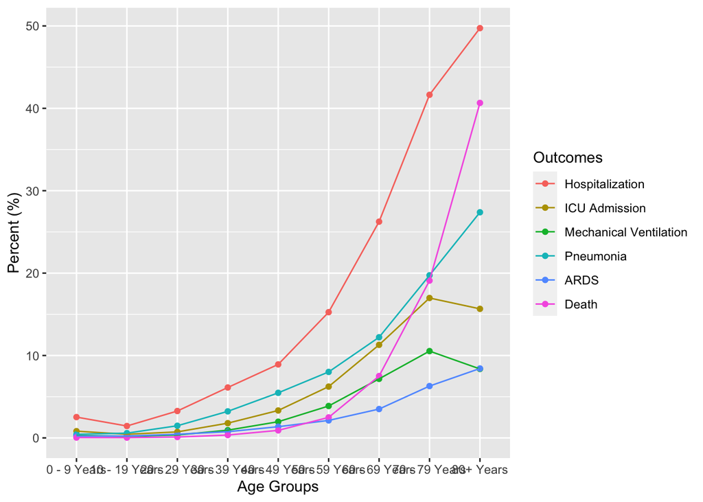

```r
## Graph for Age Population
age_graph <- df %>%
  mutate(age_group = relevel(age_group,"0 - 9 Years")) %>%
  filter(!is.na(df$age_group) & df$age_group != "Unknown") %>%
  group_by(age_group) %>%
  summarize(
    hosp_yn  = mean(hosp_yn == "Yes", na.rm = TRUE),
    icu_yn  = mean(icu_yn == "Yes", na.rm = TRUE),
    mechvent_yn = mean(mechvent_yn == "Yes", na.rm = TRUE),
    pna_yn = mean(pna_yn == "Yes", na.rm = TRUE),
    acuterespdistress_yn = mean(acuterespdistress_yn == "Yes", na.rm = TRUE),
    death_yn = mean(death_yn == "Yes", na.rm = TRUE)) %>%
  as.data.frame() %>%
  reshape::melt(id =c("age_group")) %>%
  mutate(value = value*100)

ggplot(data=age_graph, aes(x=age_group, y=value, group = variable, color=variable)) +
  geom_point() +
  geom_line() +
  labs(x = "Age Groups", y = "Percent (%)") +
  scale_color_discrete(name = "Outcomes",
                      breaks = c("hosp_yn","icu_yn","mechvent_yn","pna_yn","acuterespdistress_yn","death_yn"),
                      labels = c("Hospitalization","ICU Admission","Mechanical Ventilation","Pneumonia","ARDS","Death"))
```

```r
ggsave("figure_age.tiff", width = 9, height = 6.5, units = c("in"), dpi = 1200)
```

Time for the chunk UNIVARIATE-SPECIAL POPULATIONS to run: 0.145139161348343 hours

## 3.2 Univariate Analysis by Dependent Variables

- Dependent Variables include: hosp_yn, icu_yn, mechvent_yn, pna_yn, acuterespdistress_yn, death_yn.

```r
for (i in 1:length(dep_vars)){
  stratify <- dep_vars[i]
  print(paste("Outcome:", dep_vars[i]))

  fischer_var = c()
  cat_vars <- colnames(df[,sapply(df, function(x) is.factor(x))])
  cat_vars <- cat_vars[cat_vars %in% vars]
  for (i in 1:length(cat_vars)) {
    if(sum(chisq.test(table(df[,cat_vars[i]],df[,stratify]))$expected < 5) > 0) {
      fischer_var[i] <- cat_vars[i]
    }
  }
  fischer_var <- fischer_var[!is.na(fischer_var)]

cat('\n\n<!-- -->\n\n')
  print(kableone(print(
    CreateTableOne(vars = vars, data = df, strata = stratify, argsExact = list(workspace = 2*10^5,simulate.p.value=TRUE)),
    exact = fischer_var,
    showAllLevels = TRUE,
    missing = TRUE
  )))
cat('\n\n<!-- -->\n\n')
}
```

[1] “Outcome: hosp_yn”

|  | level | No | Yes | p | test | Missing |
| --- | --- | --- | --- | --- | --- | --- |
| n |  | 1526273 | 238638 |  |  |  |
| sex (%) | Male | 704676 ( 46.6) | 125370 ( 53.0) | <0.001 |  | 0.8 |
|  | Female | 801284 ( 52.9) | 110752 ( 46.8) |  |  |  |
|  | Other or Unknown | 7465 ( 0.5) | 392 ( 0.2) |  |  |  |
| age_group (%) | 10 - 19 Years | 184084 ( 12.1) | 2700 ( 1.1) | <0.001 |  | 0.3 |
|  | 0 - 9 Years | 67920 ( 4.5) | 1762 ( 0.7) |  |  |  |
|  | 20 - 29 Years | 314677 ( 20.7) | 10621 ( 4.5) |  |  |  |
|  | 30 - 39 Years | 256626 ( 16.9) | 16729 ( 7.0) |  |  |  |
|  | 40 - 49 Years | 233556 ( 15.4) | 22882 ( 9.6) |  |  |  |
|  | 50 - 59 Years | 208382 ( 13.7) | 37530 ( 15.8) |  |  |  |
|  | 60 - 69 Years | 138488 ( 9.1) | 49283 ( 20.7) |  |  |  |
|  | 70 - 79 Years | 68843 ( 4.5) | 49124 ( 20.7) |  |  |  |
|  | 80+ Years | 47472 ( 3.1) | 46972 ( 19.8) |  |  |  |
|  | Unknown | 240 ( 0.0) | 7 ( 0.0) |  |  |  |
| race_ethnicity_combined (%) | White, Non-Hispanic | 659111 ( 45.0) | 85297 ( 37.3) | <0.001 |  | 5.4 |
|  | American Indian/Alaska Native, Non-Hispanic | 5932 ( 0.4) | 800 ( 0.3) |  |  |  |
|  | Asian, Non-Hispanic | 27177 ( 1.9) | 7293 ( 3.2) |  |  |  |
|  | Black, Non-Hispanic | 131922 ( 9.0) | 35761 ( 15.6) |  |  |  |
|  | Hispanic/Latino | 290304 ( 19.8) | 38252 ( 16.7) |  |  |  |
|  | Multiple/Other, Non-Hispanic | 33962 ( 2.3) | 11389 ( 5.0) |  |  |  |
|  | Native Hawaiian/Other Pacific Islander, Non-Hispanic | 9589 ( 0.7) | 857 ( 0.4) |  |  |  |
|  | Unknown | 308185 ( 21.0) | 49002 ( 21.4) |  |  |  |
| res_region (%) | Northeast | 226560 ( 14.8) | 121344 ( 50.9) | <0.001 |  | 0.0 |
|  | Midwest | 205617 ( 13.5) | 40928 ( 17.2) |  |  |  |
|  | South | 555448 ( 36.4) | 44790 ( 18.8) |  |  |  |
|  | Pacific | 535519 ( 35.1) | 31079 ( 13.0) |  |  |  |
|  | US Territory or Unknown | 2658 ( 0.2) | 412 ( 0.2) |  |  |  |
| hc_work_yn (%) | No | 1030239 ( 82.7) | 79142 ( 59.4) | <0.001 |  | 41.4 |
|  | Unknown | 121375 ( 9.7) | 49964 ( 37.5) |  |  |  |
|  | Yes | 94432 ( 7.6) | 4191 ( 3.1) |  |  |  |
| medcond_yn (%) | No | 480842 ( 46.7) | 23681 ( 11.7) | <0.001 |  | 38.2 |
|  | Unknown | 148967 ( 14.5) | 53246 ( 26.3) |  |  |  |
|  | Yes | 400533 ( 38.9) | 125449 ( 62.0) |  |  |  |
| hosp_yn (%) | No | 1526273 (100.0) | 0 ( 0.0) | <0.001 |  | 53.5 |
|  | Yes | 0 ( 0.0) | 238638 (100.0) |  |  |  |
| icu_yn (%) | No | 653888 ( 99.9) | 71742 ( 65.2) | <0.001 |  | 79.3 |
|  | Yes | 860 ( 0.1) | 38292 ( 34.8) |  |  |  |
| mechvent_yn (%) | No | 502766 ( 99.9) | 61123 ( 77.3) | <0.001 |  | 84.1 |
|  | Yes | 265 ( 0.1) | 17923 ( 22.7) |  |  |  |
| pna_yn (%) | No | 686834 ( 98.1) | 29367 ( 45.5) | <0.001 |  | 79.1 |
|  | Yes | 13586 ( 1.9) | 35215 ( 54.5) |  |  |  |
| acuterespdistress_yn (%) | No | 706132 ( 99.6) | 45211 ( 80.5) | <0.001 |  | 79.2 |
|  | Yes | 2845 ( 0.4) | 10931 ( 19.5) |  |  |  |
| death_yn (%) | No | 993345 ( 98.8) | 91502 ( 63.1) | <0.001 |  | 54.6 |
|  | Yes | 12352 ( 1.2) | 53588 ( 36.9) |  |  |  |

[1] “Outcome: icu_yn”

|  | level | No | Yes | p | test | Missing |
| --- | --- | --- | --- | --- | --- | --- |
| n |  | 747280 | 39152 |  |  |  |
| sex (%) | Male | 347674 ( 46.9) | 23365 ( 60.5) | <0.001 |  | 0.8 |
|  | Female | 392767 ( 53.0) | 15211 ( 39.4) |  |  |  |
|  | Other or Unknown | 839 ( 0.1) | 41 ( 0.1) |  |  |  |
| age_group (%) | 10 - 19 Years | 87811 ( 11.8) | 391 ( 1.0) | <0.001 | exact | 0.3 |
|  | 0 - 9 Years | 29510 ( 4.0) | 244 ( 0.6) |  |  |  |
|  | 20 - 29 Years | 143105 ( 19.2) | 1053 ( 2.7) |  |  |  |
|  | 30 - 39 Years | 118234 ( 15.9) | 2155 ( 5.5) |  |  |  |
|  | 40 - 49 Years | 111651 ( 15.0) | 3846 ( 9.9) |  |  |  |
|  | 50 - 59 Years | 103827 ( 14.0) | 6895 ( 17.7) |  |  |  |
|  | 60 - 69 Years | 75165 ( 10.1) | 9571 ( 24.6) |  |  |  |
|  | 70 - 79 Years | 42858 ( 5.8) | 8767 ( 22.6) |  |  |  |
|  | 80+ Years | 32065 ( 4.3) | 5956 ( 15.3) |  |  |  |
|  | Unknown | 49 ( 0.0) | 0 ( 0.0) |  |  |  |
| race_ethnicity_combined (%) | White, Non-Hispanic | 358008 ( 49.8) | 14973 ( 40.8) | <0.001 |  | 5.4 |
|  | American Indian/Alaska Native, Non-Hispanic | 2352 ( 0.3) | 251 ( 0.7) |  |  |  |
|  | Asian, Non-Hispanic | 15015 ( 2.1) | 1453 ( 4.0) |  |  |  |
|  | Black, Non-Hispanic | 55674 ( 7.8) | 5824 ( 15.9) |  |  |  |
|  | Hispanic/Latino | 148786 ( 20.7) | 7038 ( 19.2) |  |  |  |
|  | Multiple/Other, Non-Hispanic | 14893 ( 2.1) | 1475 ( 4.0) |  |  |  |
|  | Native Hawaiian/Other Pacific Islander, Non-Hispanic | 5871 ( 0.8) | 303 ( 0.8) |  |  |  |
|  | Unknown | 117596 ( 16.4) | 5402 ( 14.7) |  |  |  |
| res_region (%) | Northeast | 147113 ( 19.7) | 13438 ( 34.3) | <0.001 |  | 0.0 |
|  | Midwest | 169636 ( 22.7) | 8071 ( 20.6) |  |  |  |
|  | South | 156942 ( 21.0) | 9967 ( 25.5) |  |  |  |
|  | Pacific | 271515 ( 36.3) | 7575 ( 19.4) |  |  |  |
|  | US Territory or Unknown | 1769 ( 0.2) | 74 ( 0.2) |  |  |  |
| hc_work_yn (%) | No | 482574 ( 76.1) | 16608 ( 62.7) | <0.001 |  | 41.4 |
|  | Unknown | 102839 ( 16.2) | 9104 ( 34.4) |  |  |  |
|  | Yes | 48499 ( 7.7) | 774 ( 2.9) |  |  |  |
| medcond_yn (%) | No | 258280 ( 47.5) | 4849 ( 14.0) | <0.001 |  | 38.2 |
|  | Unknown | 21432 ( 3.9) | 4218 ( 12.1) |  |  |  |
|  | Yes | 263878 ( 48.5) | 25656 ( 73.9) |  |  |  |
| hosp_yn (%) | No | 653888 ( 90.1) | 860 ( 2.2) | <0.001 |  | 53.5 |
|  | Yes | 71742 ( 9.9) | 38292 ( 97.8) |  |  |  |
| icu_yn (%) | No | 747280 (100.0) | 0 ( 0.0) | <0.001 |  | 79.3 |
|  | Yes | 0 ( 0.0) | 39152 (100.0) |  |  |  |
| mechvent_yn (%) | No | 523599 ( 99.8) | 10720 ( 42.6) | <0.001 |  | 84.1 |
|  | Yes | 1168 ( 0.2) | 14450 ( 57.4) |  |  |  |
| pna_yn (%) | No | 496577 ( 95.4) | 5114 ( 31.1) | <0.001 |  | 79.1 |
|  | Yes | 23745 ( 4.6) | 11313 ( 68.9) |  |  |  |
| acuterespdistress_yn (%) | No | 511061 ( 99.2) | 8391 ( 57.1) | <0.001 |  | 79.2 |
|  | Yes | 4219 ( 0.8) | 6309 ( 42.9) |  |  |  |
| death_yn (%) | No | 593763 ( 97.9) | 15228 ( 48.3) | <0.001 |  | 54.6 |
|  | Yes | 12811 ( 2.1) | 16283 ( 51.7) |  |  |  |

[1] “Outcome: mechvent_yn”

|  | level | No | Yes | p | test | Missing |
| --- | --- | --- | --- | --- | --- | --- |
| n |  | 585626 | 18244 |  |  |  |
| sex (%) | Male | 268188 ( 46.3) | 11301 ( 62.8) | <0.001 |  | 0.8 |
|  | Female | 310709 ( 53.6) | 6688 ( 37.1) |  |  |  |
|  | Other or Unknown | 892 ( 0.2) | 17 ( 0.1) |  |  |  |
| age_group (%) | 10 - 19 Years | 61320 ( 10.5) | 113 ( 0.6) | <0.001 | exact | 0.3 |
|  | 0 - 9 Years | 21726 ( 3.7) | 64 ( 0.4) |  |  |  |
|  | 20 - 29 Years | 109418 ( 18.8) | 388 ( 2.1) |  |  |  |
|  | 30 - 39 Years | 92693 ( 15.9) | 879 ( 4.9) |  |  |  |
|  | 40 - 49 Years | 86802 ( 14.9) | 1740 ( 9.6) |  |  |  |
|  | 50 - 59 Years | 85671 ( 14.7) | 3453 ( 19.1) |  |  |  |
|  | 60 - 69 Years | 62966 ( 10.8) | 4862 ( 26.8) |  |  |  |
|  | 70 - 79 Years | 35894 ( 6.2) | 4228 ( 23.3) |  |  |  |
|  | 80+ Years | 26196 ( 4.5) | 2393 ( 13.2) |  |  |  |
|  | Unknown | 49 ( 0.0) | 0 ( 0.0) |  |  |  |
| race_ethnicity_combined (%) | White, Non-Hispanic | 261068 ( 46.8) | 5468 ( 32.0) | <0.001 |  | 5.4 |
|  | American Indian/Alaska Native, Non-Hispanic | 1589 ( 0.3) | 92 ( 0.5) |  |  |  |
|  | Asian, Non-Hispanic | 12893 ( 2.3) | 878 ( 5.1) |  |  |  |
|  | Black, Non-Hispanic | 48201 ( 8.6) | 3009 ( 17.6) |  |  |  |
|  | Hispanic/Latino | 119387 ( 21.4) | 4143 ( 24.3) |  |  |  |
|  | Multiple/Other, Non-Hispanic | 13075 ( 2.3) | 907 ( 5.3) |  |  |  |
|  | Native Hawaiian/Other Pacific Islander, Non-Hispanic | 2616 ( 0.5) | 113 ( 0.7) |  |  |  |
|  | Unknown | 99372 ( 17.8) | 2474 ( 14.5) |  |  |  |
| res_region (%) | Northeast | 144925 ( 24.8) | 9589 ( 52.6) | <0.001 |  | 0.0 |
|  | Midwest | 149336 ( 25.5) | 2336 ( 12.8) |  |  |  |
|  | South | 138483 ( 23.7) | 2518 ( 13.8) |  |  |  |
|  | Pacific | 150151 ( 25.7) | 3717 ( 20.4) |  |  |  |
|  | US Territory or Unknown | 2424 ( 0.4) | 69 ( 0.4) |  |  |  |
| hc_work_yn (%) | No | 394243 ( 75.0) | 6168 ( 61.8) | <0.001 |  | 41.4 |
|  | Unknown | 91212 ( 17.3) | 3512 ( 35.2) |  |  |  |
|  | Yes | 40321 ( 7.7) | 301 ( 3.0) |  |  |  |
| medcond_yn (%) | No | 255660 ( 50.2) | 1843 ( 10.9) | <0.001 |  | 38.2 |
|  | Unknown | 19858 ( 3.9) | 2026 ( 12.0) |  |  |  |
|  | Yes | 233616 ( 45.9) | 12964 ( 77.0) |  |  |  |
| hosp_yn (%) | No | 502766 ( 89.2) | 265 ( 1.5) | <0.001 |  | 53.5 |
|  | Yes | 61123 ( 10.8) | 17923 ( 98.5) |  |  |  |
| icu_yn (%) | No | 523599 ( 98.0) | 1168 ( 7.5) | <0.001 |  | 79.3 |
|  | Yes | 10720 ( 2.0) | 14450 ( 92.5) |  |  |  |
| mechvent_yn (%) | No | 585626 (100.0) | 0 ( 0.0) | <0.001 |  | 84.1 |
|  | Yes | 0 ( 0.0) | 18244 (100.0) |  |  |  |
| pna_yn (%) | No | 433578 ( 95.2) | 1431 ( 22.5) | <0.001 |  | 79.1 |
|  | Yes | 22007 ( 4.8) | 4920 ( 77.5) |  |  |  |
| acuterespdistress_yn (%) | No | 448045 ( 99.0) | 2245 ( 38.7) | <0.001 |  | 79.2 |
|  | Yes | 4650 ( 1.0) | 3553 ( 61.3) |  |  |  |
| death_yn (%) | No | 503270 ( 97.7) | 3901 ( 26.1) | <0.001 |  | 54.6 |
|  | Yes | 11932 ( 2.3) | 11040 ( 73.9) |  |  |  |

[1] “Outcome: pna_yn”

|  | level | No | Yes | p | test | Missing |
| --- | --- | --- | --- | --- | --- | --- |
| n |  | 741769 | 50373 |  |  |  |
| sex (%) | Male | 338058 ( 46.1) | 25756 ( 52.0) | <0.001 |  | 0.8 |
|  | Female | 395223 ( 53.8) | 23762 ( 48.0) |  |  |  |
|  | Other or Unknown | 725 ( 0.1) | 25 ( 0.1) |  |  |  |
| age_group (%) | 10 - 19 Years | 91902 ( 12.5) | 535 ( 1.1) | <0.001 | exact | 0.3 |
|  | 0 - 9 Years | 32670 ( 4.4) | 144 ( 0.3) |  |  |  |
|  | 20 - 29 Years | 147386 ( 20.0) | 2208 ( 4.4) |  |  |  |
|  | 30 - 39 Years | 119006 ( 16.1) | 3964 ( 7.9) |  |  |  |
|  | 40 - 49 Years | 112487 ( 15.2) | 6512 ( 13.0) |  |  |  |
|  | 50 - 59 Years | 103588 ( 14.0) | 9019 ( 18.1) |  |  |  |
|  | 60 - 69 Years | 71369 ( 9.7) | 9932 ( 19.9) |  |  |  |
|  | 70 - 79 Years | 37033 ( 5.0) | 9106 ( 18.2) |  |  |  |
|  | 80+ Years | 22643 ( 3.1) | 8539 ( 17.1) |  |  |  |
|  | Unknown | 38 ( 0.0) | 1 ( 0.0) |  |  |  |
| race_ethnicity_combined (%) | White, Non-Hispanic | 331478 ( 46.7) | 21338 ( 45.3) | <0.001 |  | 5.4 |
|  | American Indian/Alaska Native, Non-Hispanic | 3148 ( 0.4) | 269 ( 0.6) |  |  |  |
|  | Asian, Non-Hispanic | 12662 ( 1.8) | 1144 ( 2.4) |  |  |  |
|  | Black, Non-Hispanic | 65340 ( 9.2) | 6508 ( 13.8) |  |  |  |
|  | Hispanic/Latino | 148950 ( 21.0) | 8281 ( 17.6) |  |  |  |
|  | Multiple/Other, Non-Hispanic | 13048 ( 1.8) | 1774 ( 3.8) |  |  |  |
|  | Native Hawaiian/Other Pacific Islander, Non-Hispanic | 4858 ( 0.7) | 289 ( 0.6) |  |  |  |
|  | Unknown | 129776 ( 18.3) | 7518 ( 16.0) |  |  |  |
| res_region (%) | Northeast | 114735 ( 15.5) | 15549 ( 30.9) | <0.001 |  | 0.0 |
|  | Midwest | 149497 ( 20.2) | 6966 ( 13.8) |  |  |  |
|  | South | 273160 ( 36.8) | 16179 ( 32.1) |  |  |  |
|  | Pacific | 202174 ( 27.3) | 11547 ( 22.9) |  |  |  |
|  | US Territory or Unknown | 1943 ( 0.3) | 97 ( 0.2) |  |  |  |
| hc_work_yn (%) | No | 521017 ( 80.4) | 30040 ( 75.1) | <0.001 |  | 41.4 |
|  | Unknown | 79965 ( 12.3) | 7934 ( 19.8) |  |  |  |
|  | Yes | 47021 ( 7.3) | 2020 ( 5.1) |  |  |  |
| medcond_yn (%) | No | 346594 ( 51.7) | 8666 ( 18.0) | <0.001 |  | 38.2 |
|  | Unknown | 38354 ( 5.7) | 4419 ( 9.2) |  |  |  |
|  | Yes | 285850 ( 42.6) | 34935 ( 72.8) |  |  |  |
| hosp_yn (%) | No | 686834 ( 95.9) | 13586 ( 27.8) | <0.001 |  | 53.5 |
|  | Yes | 29367 ( 4.1) | 35215 ( 72.2) |  |  |  |
| icu_yn (%) | No | 496577 ( 99.0) | 23745 ( 67.7) | <0.001 |  | 79.3 |
|  | Yes | 5114 ( 1.0) | 11313 ( 32.3) |  |  |  |
| mechvent_yn (%) | No | 433578 ( 99.7) | 22007 ( 81.7) | <0.001 |  | 84.1 |
|  | Yes | 1431 ( 0.3) | 4920 ( 18.3) |  |  |  |
| pna_yn (%) | No | 741769 (100.0) | 0 ( 0.0) | <0.001 |  | 79.1 |
|  | Yes | 0 ( 0.0) | 50373 (100.0) |  |  |  |
| acuterespdistress_yn (%) | No | 723165 ( 99.6) | 25953 ( 75.1) | <0.001 |  | 79.2 |
|  | Yes | 3116 ( 0.4) | 8614 ( 24.9) |  |  |  |
| death_yn (%) | No | 634775 ( 98.9) | 32019 ( 72.8) | <0.001 |  | 54.6 |
|  | Yes | 7036 ( 1.1) | 11983 ( 27.2) |  |  |  |

[1] “Outcome: acuterespdistress_yn”

|  | level | No | Yes | p | test | Missing |
| --- | --- | --- | --- | --- | --- | --- |
| n |  | 777033 | 14054 |  |  |  |
| sex (%) | Male | 355360 ( 46.2) | 7590 ( 55.1) | <0.001 |  | 0.8 |
|  | Female | 412204 ( 53.6) | 6172 ( 44.8) |  |  |  |
|  | Other or Unknown | 1044 ( 0.1) | 11 ( 0.1) |  |  |  |
| age_group (%) | 10 - 19 Years | 92944 ( 12.0) | 215 ( 1.5) | <0.001 | exact | 0.3 |
|  | 0 - 9 Years | 33174 ( 4.3) | 68 ( 0.5) |  |  |  |
|  | 20 - 29 Years | 150949 ( 19.5) | 675 ( 4.9) |  |  |  |
|  | 30 - 39 Years | 123237 ( 15.9) | 937 ( 6.7) |  |  |  |
|  | 40 - 49 Years | 117788 ( 15.2) | 1624 ( 11.7) |  |  |  |
|  | 50 - 59 Years | 109908 ( 14.2) | 2383 ( 17.1) |  |  |  |
|  | 60 - 69 Years | 77158 ( 10.0) | 2801 ( 20.1) |  |  |  |
|  | 70 - 79 Years | 41518 ( 5.4) | 2788 ( 20.0) |  |  |  |
|  | 80+ Years | 26358 ( 3.4) | 2426 ( 17.4) |  |  |  |
|  | Unknown | 36 ( 0.0) | 0 ( 0.0) |  |  |  |
| race_ethnicity_combined (%) | White, Non-Hispanic | 345965 ( 46.6) | 5815 ( 44.5) | <0.001 |  | 5.4 |
|  | American Indian/Alaska Native, Non-Hispanic | 3270 ( 0.4) | 81 ( 0.6) |  |  |  |
|  | Asian, Non-Hispanic | 13369 ( 1.8) | 449 ( 3.4) |  |  |  |
|  | Black, Non-Hispanic | 68306 ( 9.2) | 1873 ( 14.3) |  |  |  |
|  | Hispanic/Latino | 156623 ( 21.1) | 2652 ( 20.3) |  |  |  |
|  | Multiple/Other, Non-Hispanic | 13701 ( 1.8) | 461 ( 3.5) |  |  |  |
|  | Native Hawaiian/Other Pacific Islander, Non-Hispanic | 5170 ( 0.7) | 96 ( 0.7) |  |  |  |
|  | Unknown | 135683 ( 18.3) | 1649 ( 12.6) |  |  |  |
| res_region (%) | Northeast | 119140 ( 15.3) | 2637 ( 18.8) | <0.001 |  | 0.0 |
|  | Midwest | 150139 ( 19.3) | 2223 ( 15.8) |  |  |  |
|  | South | 281024 ( 36.2) | 4874 ( 34.7) |  |  |  |
|  | Pacific | 224474 ( 28.9) | 4256 ( 30.3) |  |  |  |
|  | US Territory or Unknown | 1984 ( 0.3) | 45 ( 0.3) |  |  |  |
| hc_work_yn (%) | No | 547543 ( 80.6) | 8553 ( 77.0) | <0.001 |  | 41.4 |
|  | Unknown | 82626 ( 12.2) | 2063 ( 18.6) |  |  |  |
|  | Yes | 48946 ( 7.2) | 485 ( 4.4) |  |  |  |
| medcond_yn (%) | No | 360621 ( 51.2) | 2125 ( 15.6) | <0.001 |  | 38.2 |
|  | Unknown | 38609 ( 5.5) | 1118 ( 8.2) |  |  |  |
|  | Yes | 305274 ( 43.3) | 10397 ( 76.2) |  |  |  |
| hosp_yn (%) | No | 706132 ( 94.0) | 2845 ( 20.7) | <0.001 |  | 53.5 |
|  | Yes | 45211 ( 6.0) | 10931 ( 79.3) |  |  |  |
| icu_yn (%) | No | 511061 ( 98.4) | 4219 ( 40.1) | <0.001 |  | 79.3 |
|  | Yes | 8391 ( 1.6) | 6309 ( 59.9) |  |  |  |
| mechvent_yn (%) | No | 448045 ( 99.5) | 4650 ( 56.7) | <0.001 |  | 84.1 |
|  | Yes | 2245 ( 0.5) | 3553 ( 43.3) |  |  |  |
| pna_yn (%) | No | 723165 ( 96.5) | 3116 ( 26.6) | <0.001 |  | 79.1 |
|  | Yes | 25953 ( 3.5) | 8614 ( 73.4) |  |  |  |
| acuterespdistress_yn (%) | No | 777033 (100.0) | 0 ( 0.0) | <0.001 |  | 79.2 |
|  | Yes | 0 ( 0.0) | 14054 (100.0) |  |  |  |
| death_yn (%) | No | 649030 ( 98.5) | 6937 ( 54.3) | <0.001 |  | 54.6 |
|  | Yes | 9726 ( 1.5) | 5834 ( 45.7) |  |  |  |

[1] “Outcome: death_yn”

|  | level | No | Yes | p | test | Missing |
| --- | --- | --- | --- | --- | --- | --- |
| n |  | 1638857 | 83810 |  |  |  |
| sex (%) | Male | 764216 ( 47.1) | 44484 ( 53.5) | <0.001 |  | 0.8 |
|  | Female | 857348 ( 52.8) | 38464 ( 46.3) |  |  |  |
|  | Other or Unknown | 2199 ( 0.1) | 140 ( 0.2) |  |  |  |
| age_group (%) | 10 - 19 Years | 185758 ( 11.4) | 68 ( 0.1) | <0.001 |  | 0.3 |
|  | 0 - 9 Years | 70865 ( 4.3) | 31 ( 0.0) |  |  |  |
|  | 20 - 29 Years | 318612 ( 19.5) | 348 ( 0.4) |  |  |  |
|  | 30 - 39 Years | 265230 ( 16.2) | 925 ( 1.1) |  |  |  |
|  | 40 - 49 Years | 245839 ( 15.1) | 2268 ( 2.7) |  |  |  |
|  | 50 - 59 Years | 234894 ( 14.4) | 5999 ( 7.2) |  |  |  |
|  | 60 - 69 Years | 164760 ( 10.1) | 13373 ( 16.0) |  |  |  |
|  | 70 - 79 Years | 88759 ( 5.4) | 20947 ( 25.1) |  |  |  |
|  | 80+ Years | 57655 ( 3.5) | 39501 ( 47.3) |  |  |  |
|  | Unknown | 156 ( 0.0) | 2 ( 0.0) |  |  |  |
| race_ethnicity_combined (%) | White, Non-Hispanic | 733050 ( 46.5) | 38223 ( 47.5) | <0.001 |  | 5.4 |
|  | American Indian/Alaska Native, Non-Hispanic | 6639 ( 0.4) | 172 ( 0.2) |  |  |  |
|  | Asian, Non-Hispanic | 35508 ( 2.3) | 2401 ( 3.0) |  |  |  |
|  | Black, Non-Hispanic | 156581 ( 9.9) | 10615 ( 13.2) |  |  |  |
|  | Hispanic/Latino | 270583 ( 17.2) | 9060 ( 11.3) |  |  |  |
|  | Multiple/Other, Non-Hispanic | 38690 ( 2.5) | 4068 ( 5.1) |  |  |  |
|  | Native Hawaiian/Other Pacific Islander, Non-Hispanic | 5880 ( 0.4) | 115 ( 0.1) |  |  |  |
|  | Unknown | 330597 ( 21.0) | 15733 ( 19.6) |  |  |  |
| res_region (%) | Northeast | 230707 ( 14.1) | 48837 ( 58.3) | <0.001 |  | 0.0 |
|  | Midwest | 564618 ( 34.5) | 11394 ( 13.6) |  |  |  |
|  | South | 614737 ( 37.5) | 15601 ( 18.6) |  |  |  |
|  | Pacific | 225800 ( 13.8) | 7832 ( 9.3) |  |  |  |
|  | US Territory or Unknown | 2522 ( 0.2) | 125 ( 0.1) |  |  |  |
| hc_work_yn (%) | No | 838522 ( 65.3) | 24298 ( 49.2) | <0.001 |  | 41.4 |
|  | Unknown | 349898 ( 27.2) | 24826 ( 50.3) |  |  |  |
|  | Yes | 95633 ( 7.4) | 233 ( 0.5) |  |  |  |
| medcond_yn (%) | No | 554653 ( 43.5) | 3881 ( 5.3) | <0.001 |  | 38.2 |
|  | Unknown | 314291 ( 24.7) | 22252 ( 30.7) |  |  |  |
|  | Yes | 405270 ( 31.8) | 46449 ( 64.0) |  |  |  |
| hosp_yn (%) | No | 993345 ( 91.6) | 12352 ( 18.7) | <0.001 |  | 53.5 |
|  | Yes | 91502 ( 8.4) | 53588 ( 81.3) |  |  |  |
| icu_yn (%) | No | 593763 ( 97.5) | 12811 ( 44.0) | <0.001 |  | 79.3 |
|  | Yes | 15228 ( 2.5) | 16283 ( 56.0) |  |  |  |
| mechvent_yn (%) | No | 503270 ( 99.2) | 11932 ( 51.9) | <0.001 |  | 84.1 |
|  | Yes | 3901 ( 0.8) | 11040 ( 48.1) |  |  |  |
| pna_yn (%) | No | 634775 ( 95.2) | 7036 ( 37.0) | <0.001 |  | 79.1 |
|  | Yes | 32019 ( 4.8) | 11983 ( 63.0) |  |  |  |
| acuterespdistress_yn (%) | No | 649030 ( 98.9) | 9726 ( 62.5) | <0.001 |  | 79.2 |
|  | Yes | 6937 ( 1.1) | 5834 ( 37.5) |  |  |  |
| death_yn (%) | No | 1638857 (100.0) | 0 ( 0.0) | <0.001 |  | 54.6 |
|  | Yes | 0 ( 0.0) | 83810 (100.0) |  |  |  |

Time for the chunk UNIVARIATE ANALYSIS DEPENDENT to run: 0.031475263370408 hours

## 3.3 Adjusted Model by Dependent Variables

```r
#Analysis

figure.forest = list()

for(i in 1:length(dep_vars)){
#creating reference table
ref.table <- data.frame(
  or = 1,
  x2_5_percent = 1,
  x97_5_percent = 1,
  p = NA,
  variable = c("sexMale", "age_group 10 - 19 Years", "race_ethnicity_combinedWhite, Non-Hispanic", "res_regionNortheast", "hc_work_ynNo", "medcond_ynNo"),
  dependent = dep_vars[i],
  sig_text = NA)


  print(paste("Outcome:", dep_vars[i]))
  form <- as.formula(paste(dep_vars[i] ,"~", paste0(ind_vars, collapse = " + ")))
  mod <- glm(formula = form, data = df, family = binomial) %>%
    MASS::stepAIC(trace = TRUE, direction = "both")

cat('\n\n<!-- -->\n\n')
  print(kableone(print(cbind(exp(cbind(OR = coef(mod), confint.default(mod))), P=summary(mod)$coefficients[,4]))))
cat('\n\n<!-- -->\n\n')

## CREATING OR PLOT
df %>%
  mutate(race_ethnicity_combined = gsub(", Non-Hispanic", "", race_ethnicity_combined)) %>%
  mutate(res_region = gsub("US Territory or Unknown", "Territories of the United States or Unknown", res_region)) %>%
  mutate(hosp_yn = ff_label(hosp_yn, "Hospitalization")) %>%
  mutate(icu_yn = ff_label(icu_yn, "ICU Admission")) %>%
  mutate(mechvent_yn = ff_label(mechvent_yn, "Mechanical Ventilation/Intubation")) %>%
  mutate(pna_yn = ff_label(pna_yn, "Pneumonia")) %>%
  mutate(acuterespdistress_yn = ff_label(acuterespdistress_yn, "Acute Respiratory Distress Syndrome")) %>%
  mutate(death_yn = ff_label(death_yn, "Death")) %>%
  mutate(sex = ff_label(sex, "Sex")) %>%
  mutate(age_group = ff_label(age_group, "Age Group")) %>%
  mutate(race_ethnicity_combined = ff_label(race_ethnicity_combined, "Race & Ethnicity")) %>%
  mutate(res_region = ff_label(res_region, "United States Census Region")) %>%
  mutate(hc_work_yn = ff_label(hc_work_yn, "Health Care Worker")) %>%
  mutate(medcond_yn = ff_label(medcond_yn, "Pre-existing Medical Conditions")) %>%
  or_plot(dep_vars[i], ind_vars)


figure.forest[[i]] <- cbind(exp(cbind(OR = coef(mod), confint.default(mod))),P=summary(mod)$coefficients[,4]) %>%
  as.data.frame() %>%
  clean_names() %>%
  mutate(variable=rownames(.)) %>%
  `rownames<-`(seq_len(nrow(.))) %>%
  mutate(dependent=dep_vars[i]) %>%
  mutate(sig_text = paste(round(or,2), "(", round(x2_5_percent,2), "-", round(x97_5_percent,2), "), p = ", round(p,2), sep = "")) %>%
  rbind(.,ref.table) %>%
  filter(variable!="(Intercept)") %>%
  arrange(variable) %>%
  add_row(variable= "Sex", dependent=dep_vars[i]) %>%
  add_row(variable= "Age Group", dependent=dep_vars[i]) %>%
  add_row(variable= "Race & Ethnicity", dependent=dep_vars[i]) %>%
  add_row(variable= "Region", dependent=dep_vars[i]) %>%
  add_row(variable= "Healthcare Worker", dependent=dep_vars[i]) %>%
  add_row(variable= "Pre-existing Medical Conditions", dependent=dep_vars[i])

}
```

[1] “Outcome: hosp_yn” Start: AIC=541275.5 hosp_yn ~ sex + age_group + race_ethnicity_combined + res_region + hc_work_yn + medcond_yn

```
                      Df Deviance    AIC
```

541222 541276 - res_region 4 543388 543434 - sex 2 543495 543545 - race_ethnicity_combined 7 548454 548494 - medcond_yn 2 550652 550702 - hc_work_yn 2 556872 556922 - age_group 9 608182 608218

|  | OR | 2.5 % | 97.5 % | P |
| --- | --- | --- | --- | --- |
| (Intercept) | 0.0091815 | 0.0086498 | 0.0097459 | 0.0000000 |
| sexFemale | 0.7128608 | 0.7028393 | 0.7230252 | 0.0000000 |
| sexOther or Unknown | 0.3443927 | 0.2703949 | 0.4386411 | 0.0000000 |
| age_group0 - 9 Years | 1.6896493 | 1.5458332 | 1.8468452 | 0.0000000 |
| age_group20 - 29 Years | 1.9860464 | 1.8657549 | 2.1140934 | 0.0000000 |
| age_group30 - 39 Years | 3.2854028 | 3.0931751 | 3.4895767 | 0.0000000 |
| age_group40 - 49 Years | 4.9256647 | 4.6441064 | 5.2242931 | 0.0000000 |
| age_group50 - 59 Years | 7.9543815 | 7.5081950 | 8.4270834 | 0.0000000 |
| age_group60 - 69 Years | 14.1021734 | 13.3131637 | 14.9379440 | 0.0000000 |
| age_group70 - 79 Years | 27.5861262 | 26.0280502 | 29.2374707 | 0.0000000 |
| age_group80+ Years | 32.5903971 | 30.7302054 | 34.5631918 | 0.0000000 |
| age_groupUnknown | 2.4463145 | 0.3326722 | 17.9890455 | 0.3795137 |
| race_ethnicity_combinedAmerican Indian/Alaska Native, Non-Hispanic | 1.9042282 | 1.6990507 | 2.1341831 | 0.0000000 |
| race_ethnicity_combinedAsian, Non-Hispanic | 2.1464616 | 2.0481954 | 2.2494423 | 0.0000000 |
| race_ethnicity_combinedBlack, Non-Hispanic | 2.2273334 | 2.1781642 | 2.2776126 | 0.0000000 |
| race_ethnicity_combinedHispanic/Latino | 1.4696639 | 1.4376665 | 1.5023735 | 0.0000000 |
| race_ethnicity_combinedMultiple/Other, Non-Hispanic | 1.8145313 | 1.7429362 | 1.8890672 | 0.0000000 |
| race_ethnicity_combinedNative Hawaiian/Other Pacific Islander, Non-Hispanic | 2.3403522 | 2.1253807 | 2.5770670 | 0.0000000 |
| race_ethnicity_combinedUnknown | 0.9172781 | 0.8984316 | 0.9365199 | 0.0000000 |
| res_regionMidwest | 0.8444304 | 0.8262887 | 0.8629704 | 0.0000000 |
| res_regionSouth | 0.6109958 | 0.5983691 | 0.6238888 | 0.0000000 |
| res_regionPacific | 0.7653276 | 0.7475554 | 0.7835223 | 0.0000000 |
| res_regionUS Territory or Unknown | 0.7594456 | 0.6425469 | 0.8976118 | 0.0012529 |
| hc_work_ynUnknown | 3.2099017 | 3.1500162 | 3.2709258 | 0.0000000 |
| hc_work_ynYes | 0.8183146 | 0.7892490 | 0.8484506 | 0.0000000 |
| medcond_ynUnknown | 1.9889848 | 1.9425015 | 2.0365803 | 0.0000000 |
| medcond_ynYes | 2.3826455 | 2.3395430 | 2.4265420 | 0.0000000 |

```
## Note: dependent includes missing data. These are dropped.
```

[1] “Outcome: icu_yn” Start: AIC=156807.7 icu_yn ~ sex + age_group + race_ethnicity_combined + res_region + hc_work_yn + medcond_yn

```
                      Df Deviance    AIC
```

156756 156808 - sex 2 158391 158439 - res_region 4 158549 158593 - hc_work_yn 2 159065 159113 - race_ethnicity_combined 7 159157 159195 - medcond_yn 2 159444 159492 - age_group 8 172874 172910

|  | OR | 2.5 % | 97.5 % | P |
| --- | --- | --- | --- | --- |
| (Intercept) | 0.0016794 | 0.0014599 | 0.0019320 | 0.0000000 |
| sexFemale | 0.5625203 | 0.5468837 | 0.5786039 | 0.0000000 |
| sexOther or Unknown | 0.7845418 | 0.4650869 | 1.3234211 | 0.3630453 |
| age_group0 - 9 Years | 1.5859877 | 1.2795051 | 1.9658827 | 0.0000256 |
| age_group20 - 29 Years | 1.6573803 | 1.4227684 | 1.9306793 | 0.0000000 |
| age_group30 - 39 Years | 3.4429751 | 2.9840882 | 3.9724286 | 0.0000000 |
| age_group40 - 49 Years | 6.2190638 | 5.4172226 | 7.1395912 | 0.0000000 |
| age_group50 - 59 Years | 10.9482808 | 9.5619327 | 12.5356303 | 0.0000000 |
| age_group60 - 69 Years | 19.8439234 | 17.3419785 | 22.7068264 | 0.0000000 |
| age_group70 - 79 Years | 31.3624768 | 27.3891680 | 35.9121880 | 0.0000000 |
| age_group80+ Years | 29.1882753 | 25.4448966 | 33.4823690 | 0.0000000 |
| race_ethnicity_combinedAmerican Indian/Alaska Native, Non-Hispanic | 5.2789601 | 4.3401446 | 6.4208506 | 0.0000000 |
| race_ethnicity_combinedAsian, Non-Hispanic | 2.8756941 | 2.6561974 | 3.1133291 | 0.0000000 |
| race_ethnicity_combinedBlack, Non-Hispanic | 2.1402962 | 2.0494671 | 2.2351508 | 0.0000000 |
| race_ethnicity_combinedHispanic/Latino | 1.8421016 | 1.7653498 | 1.9221904 | 0.0000000 |
| race_ethnicity_combinedMultiple/Other, Non-Hispanic | 2.0964300 | 1.9237943 | 2.2845575 | 0.0000000 |
| race_ethnicity_combinedNative Hawaiian/Other Pacific Islander, Non-Hispanic | 3.9406462 | 3.3995177 | 4.5679104 | 0.0000000 |
| race_ethnicity_combinedUnknown | 1.0876427 | 1.0403502 | 1.1370850 | 0.0002122 |
| res_regionMidwest | 1.0237395 | 0.9803628 | 1.0690355 | 0.2881735 |
| res_regionSouth | 2.3327332 | 2.2295561 | 2.4406851 | 0.0000000 |
| res_regionPacific | 1.6495482 | 1.5747965 | 1.7278481 | 0.0000000 |
| res_regionUS Territory or Unknown | 0.8581366 | 0.5909285 | 1.2461717 | 0.4215332 |
| hc_work_ynUnknown | 2.4167704 | 2.3295228 | 2.5072857 | 0.0000000 |
| hc_work_ynYes | 0.7990346 | 0.7380524 | 0.8650555 | 0.0000000 |
| medcond_ynUnknown | 4.1449807 | 3.9186923 | 4.3843363 | 0.0000000 |
| medcond_ynYes | 2.0096986 | 1.9355008 | 2.0867408 | 0.0000000 |

```
## Note: dependent includes missing data. These are dropped.
```

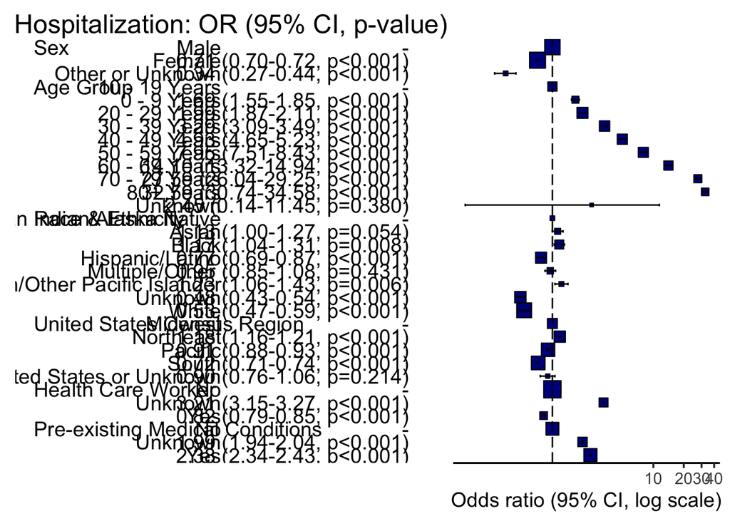

[1] “Outcome: mechvent_yn” Start: AIC=73497.95 mechvent_yn ~ sex + age_group + race_ethnicity_combined + res_region + hc_work_yn + medcond_yn

```
                      Df Deviance   AIC
```

73446 73498 - res_region 4 74111 74155 - sex 2 74316 74364 - hc_work_yn 2 74488 74536 - race_ethnicity_combined 7 74816 74854 - medcond_yn 2 74810 74858 - age_group 8 80274 80310

|  | OR | 2.5 % | 97.5 % | P |
| --- | --- | --- | --- | --- |
| (Intercept) | 0.0006338 | 0.0004871 | 0.0008246 | 0.0000000 |
| sexFemale | 0.5182147 | 0.4957027 | 0.5417491 | 0.0000000 |
| sexOther or Unknown | 0.9264738 | 0.4856949 | 1.7672692 | 0.8167126 |
| age_group0 - 9 Years | 0.9791790 | 0.6050771 | 1.5845775 | 0.9317267 |
| age_group20 - 29 Years | 1.7805381 | 1.3330028 | 2.3783266 | 0.0000938 |
| age_group30 - 39 Years | 4.1893397 | 3.1954177 | 5.4924171 | 0.0000000 |
| age_group40 - 49 Years | 8.3777362 | 6.4423783 | 10.8944958 | 0.0000000 |
| age_group50 - 59 Years | 16.0641326 | 12.4029501 | 20.8060463 | 0.0000000 |
| age_group60 - 69 Years | 29.9183638 | 23.1172112 | 38.7204357 | 0.0000000 |
| age_group70 - 79 Years | 46.6183013 | 35.9832719 | 60.3965648 | 0.0000000 |
| age_group80+ Years | 31.9574663 | 24.5700514 | 41.5660365 | 0.0000000 |
| race_ethnicity_combinedAmerican Indian/Alaska Native, Non-Hispanic | 4.3146693 | 3.1950570 | 5.8266162 | 0.0000000 |
| race_ethnicity_combinedAsian, Non-Hispanic | 3.2908343 | 2.9474453 | 3.6742294 | 0.0000000 |
| race_ethnicity_combinedBlack, Non-Hispanic | 2.4742190 | 2.3099389 | 2.6501826 | 0.0000000 |
| race_ethnicity_combinedHispanic/Latino | 1.9878694 | 1.8634634 | 2.1205807 | 0.0000000 |
| race_ethnicity_combinedMultiple/Other, Non-Hispanic | 2.2672109 | 2.0067697 | 2.5614524 | 0.0000000 |
| race_ethnicity_combinedNative Hawaiian/Other Pacific Islander, Non-Hispanic | 4.3349220 | 3.4706886 | 5.4143573 | 0.0000000 |
| race_ethnicity_combinedUnknown | 0.9504199 | 0.8879611 | 1.0172721 | 0.1425922 |
| res_regionMidwest | 0.6004116 | 0.5616655 | 0.6418306 | 0.0000000 |
| res_regionSouth | 1.1648590 | 1.0822552 | 1.2537676 | 0.0000478 |
| res_regionPacific | 1.5091017 | 1.4132755 | 1.6114253 | 0.0000000 |
| res_regionUS Territory or Unknown | 0.6946725 | 0.4424005 | 1.0907985 | 0.1135453 |
| hc_work_ynUnknown | 2.4849524 | 2.3500033 | 2.6276511 | 0.0000000 |
| hc_work_ynYes | 0.8761648 | 0.7727576 | 0.9934096 | 0.0390979 |
| medcond_ynUnknown | 4.5766409 | 4.2112641 | 4.9737185 | 0.0000000 |
| medcond_ynYes | 2.2286968 | 2.0963923 | 2.3693510 | 0.0000000 |

```
## Note: dependent includes missing data. These are dropped.
```

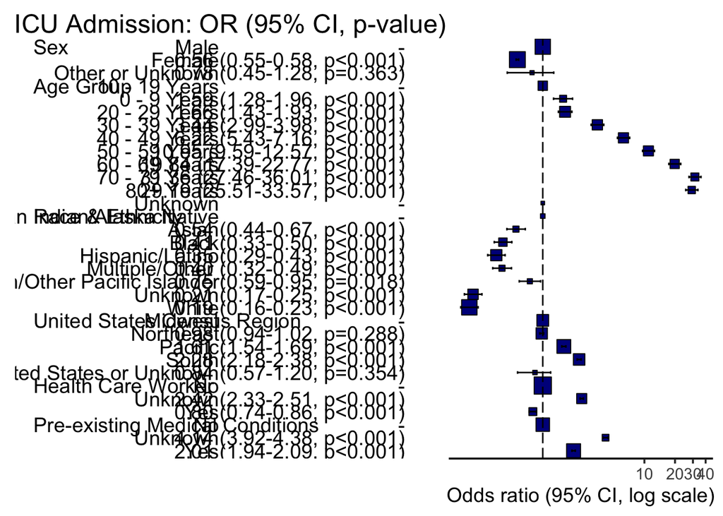

[1] “Outcome: pna_yn” Start: AIC=239195.5 pna_yn ~ sex + age_group + race_ethnicity_combined + res_region + hc_work_yn + medcond_yn

```
                      Df Deviance    AIC
```

239143 239195 - hc_work_yn 2 239168 239216 - sex 2 239889 239937 - race_ethnicity_combined 7 242067 242105 - res_region 4 243350 243394 - medcond_yn 2 244658 244706 - age_group 8 262754 262790

|  | OR | 2.5 % | 97.5 % | P |
| --- | --- | --- | --- | --- |
| (Intercept) | 0.0059469 | 0.0053331 | 0.0066313 | 0.0000000 |
| sexFemale | 0.7343670 | 0.7182343 | 0.7508621 | 0.0000000 |
| sexOther or Unknown | 0.6035261 | 0.3416049 | 1.0662720 | 0.0820377 |
| age_group0 - 9 Years | 0.6999244 | 0.5573532 | 0.8789654 | 0.0021400 |
| age_group20 - 29 Years | 2.6264212 | 2.3407485 | 2.9469582 | 0.0000000 |
| age_group30 - 39 Years | 5.7139365 | 5.1178364 | 6.3794674 | 0.0000000 |
| age_group40 - 49 Years | 9.1896112 | 8.2489275 | 10.2375679 | 0.0000000 |
| age_group50 - 59 Years | 12.5295007 | 11.2570622 | 13.9457688 | 0.0000000 |
| age_group60 - 69 Years | 18.7189723 | 16.8167918 | 20.8363122 | 0.0000000 |
| age_group70 - 79 Years | 32.1608482 | 28.8707733 | 35.8258557 | 0.0000000 |
| age_group80+ Years | 46.0331749 | 41.2828524 | 51.3301061 | 0.0000000 |
| race_ethnicity_combinedAmerican Indian/Alaska Native, Non-Hispanic | 1.6556304 | 1.3915722 | 1.9697952 | 0.0000000 |
| race_ethnicity_combinedAsian, Non-Hispanic | 1.8277378 | 1.6921207 | 1.9742241 | 0.0000000 |
| race_ethnicity_combinedBlack, Non-Hispanic | 1.8693093 | 1.8051004 | 1.9358021 | 0.0000000 |
| race_ethnicity_combinedHispanic/Latino | 1.5559353 | 1.5054617 | 1.6081011 | 0.0000000 |
| race_ethnicity_combinedMultiple/Other, Non-Hispanic | 2.1376296 | 2.0010241 | 2.2835609 | 0.0000000 |
| race_ethnicity_combinedNative Hawaiian/Other Pacific Islander, Non-Hispanic | 1.7871519 | 1.5460992 | 2.0657873 | 0.0000000 |
| race_ethnicity_combinedUnknown | 0.7576045 | 0.7329172 | 0.7831233 | 0.0000000 |
| res_regionMidwest | 0.3644835 | 0.3516489 | 0.3777866 | 0.0000000 |
| res_regionSouth | 0.4144191 | 0.4014106 | 0.4278492 | 0.0000000 |
| res_regionPacific | 0.5846092 | 0.5643215 | 0.6056262 | 0.0000000 |
| res_regionUS Territory or Unknown | 0.1986879 | 0.1428545 | 0.2763433 | 0.0000000 |
| hc_work_ynUnknown | 1.0280148 | 0.9950737 | 1.0620465 | 0.0963594 |
| hc_work_ynYes | 1.1307052 | 1.0754337 | 1.1888175 | 0.0000016 |
| medcond_ynUnknown | 3.0823864 | 2.9468134 | 3.2241967 | 0.0000000 |
| medcond_ynYes | 2.6607867 | 2.5862920 | 2.7374271 | 0.0000000 |

```
## Note: dependent includes missing data. These are dropped.
```

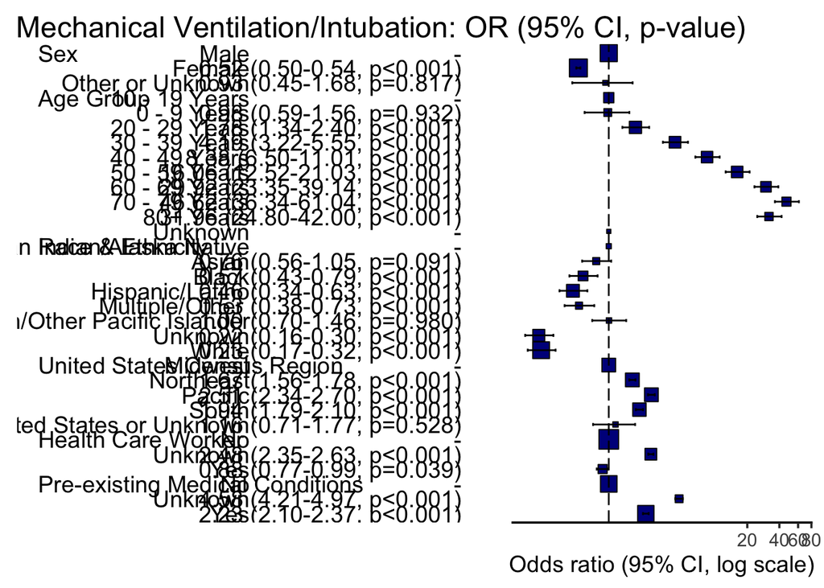

[1] “Outcome: acuterespdistress_yn” Start: AIC=94777.57 acuterespdistress_yn ~ sex + age_group + race_ethnicity_combined + res_region + hc_work_yn + medcond_yn

```
                      Df Deviance    AIC
```

94726 94778 - hc_work_yn 2 94824 94872 - sex 2 95097 95145 - res_region 4 95187 95231 - race_ethnicity_combined 7 95811 95849 - medcond_yn 2 96667 96715 - age_group 8 101867 101903

|  | OR | 2.5 % | 97.5 % | P |
| --- | --- | --- | --- | --- |
| (Intercept) | 0.0011842 | 0.0010030 | 0.0013981 | 0.0000000 |
| sexFemale | 0.6796907 | 0.6534030 | 0.7070359 | 0.0000000 |
| sexOther or Unknown | 0.5591823 | 0.2298310 | 1.3604988 | 0.2000711 |
| age_group0 - 9 Years | 0.8979031 | 0.6692086 | 1.2047513 | 0.4727428 |
| age_group20 - 29 Years | 1.8213317 | 1.5345075 | 2.1617679 | 0.0000000 |
| age_group30 - 39 Years | 2.7312736 | 2.3131435 | 3.2249859 | 0.0000000 |
| age_group40 - 49 Years | 4.5885746 | 3.9124750 | 5.3815082 | 0.0000000 |
| age_group50 - 59 Years | 6.4626505 | 5.5246838 | 7.5598627 | 0.0000000 |
| age_group60 - 69 Years | 10.4850194 | 8.9682271 | 12.2583462 | 0.0000000 |
| age_group70 - 79 Years | 19.4871812 | 16.6576240 | 22.7973829 | 0.0000000 |
| age_group80+ Years | 27.2699957 | 23.2689072 | 31.9590714 | 0.0000000 |
| race_ethnicity_combinedAmerican Indian/Alaska Native, Non-Hispanic | 2.1165539 | 1.6258727 | 2.7553204 | 0.0000000 |
| race_ethnicity_combinedAsian, Non-Hispanic | 2.3133751 | 2.0574570 | 2.6011259 | 0.0000000 |
| race_ethnicity_combinedBlack, Non-Hispanic | 1.8510895 | 1.7397201 | 1.9695883 | 0.0000000 |
| race_ethnicity_combinedHispanic/Latino | 1.7794772 | 1.6818902 | 1.8827264 | 0.0000000 |
| race_ethnicity_combinedMultiple/Other, Non-Hispanic | 2.3161963 | 2.0651980 | 2.5977003 | 0.0000000 |
| race_ethnicity_combinedNative Hawaiian/Other Pacific Islander, Non-Hispanic | 1.9134761 | 1.5234686 | 2.4033254 | 0.0000000 |
| race_ethnicity_combinedUnknown | 0.7830686 | 0.7341609 | 0.8352344 | 0.0000000 |
| res_regionMidwest | 0.8634336 | 0.8063494 | 0.9245591 | 0.0000258 |
| res_regionSouth | 0.9699254 | 0.9069307 | 1.0372956 | 0.3727993 |
| res_regionPacific | 1.5728284 | 1.4691556 | 1.6838169 | 0.0000000 |
| res_regionUS Territory or Unknown | 0.6576255 | 0.3980479 | 1.0864806 | 0.1018047 |
| hc_work_ynUnknown | 1.3701871 | 1.2882021 | 1.4573899 | 0.0000000 |
| hc_work_ynYes | 1.0257010 | 0.9301329 | 1.1310884 | 0.6110800 |
| medcond_ynUnknown | 3.4768494 | 3.1940701 | 3.7846638 | 0.0000000 |
| medcond_ynYes | 2.9847689 | 2.8262722 | 3.1521541 | 0.0000000 |

```
## Note: dependent includes missing data. These are dropped.
```

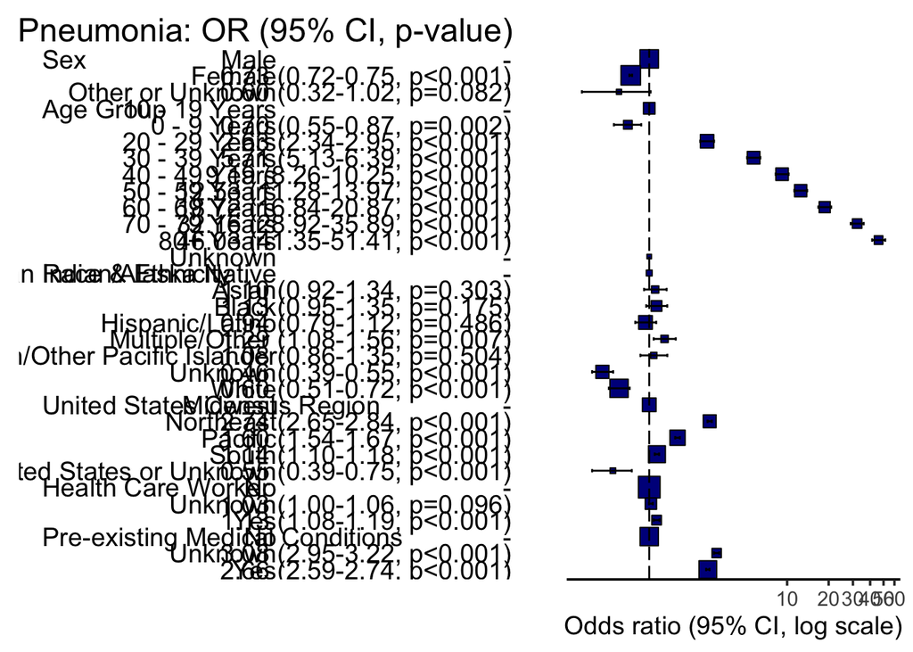

[1] “Outcome: death_yn” Start: AIC=207230 death_yn ~ sex + age_group + race_ethnicity_combined + res_region + hc_work_yn + medcond_yn

```
                      Df Deviance    AIC
```

207176 207230 - race_ethnicity_combined 7 208069 208109 - sex 2 208755 208805 - medcond_yn 2 210906 210956 - hc_work_yn 2 213133 213183 - res_region 4 215699 215745 - age_group 9 284172 284208

|  | OR | 2.5 % | 97.5 % | P |
| --- | --- | --- | --- | --- |
| (Intercept) | 0.0003316 | 0.0002364 | 4.652000e-04 | 0.0000000 |
| sexFemale | 0.6248202 | 0.6103993 | 6.395819e-01 | 0.0000000 |
| sexOther or Unknown | 0.5593596 | 0.3874404 | 8.075648e-01 | 0.0019307 |
| age_group0 - 9 Years | 1.0919741 | 0.5946986 | 2.005062e+00 | 0.7765765 |
| age_group20 - 29 Years | 2.6189148 | 1.8066202 | 3.796434e+00 | 0.0000004 |
| age_group30 - 39 Years | 6.3021633 | 4.4300580 | 8.965405e+00 | 0.0000000 |
| age_group40 - 49 Years | 16.0766723 | 11.4124409 | 2.264716e+01 | 0.0000000 |
| age_group50 - 59 Years | 41.4200221 | 29.5225849 | 5.811206e+01 | 0.0000000 |
| age_group60 - 69 Years | 119.4405252 | 85.2348985 | 1.673732e+02 | 0.0000000 |
| age_group70 - 79 Years | 317.4116834 | 226.5635802 | 4.446883e+02 | 0.0000000 |
| age_group80+ Years | 1004.4599118 | 717.0660435 | 1.407039e+03 | 0.0000000 |
| age_groupUnknown | 0.0144093 | 0.0000000 | 1.957029e+32 | 0.9157939 |
| race_ethnicity_combinedAmerican Indian/Alaska Native, Non-Hispanic | 1.7747142 | 1.4146401 | 2.226439e+00 | 0.0000007 |
| race_ethnicity_combinedAsian, Non-Hispanic | 1.6749657 | 1.5352776 | 1.827363e+00 | 0.0000000 |
| race_ethnicity_combinedBlack, Non-Hispanic | 1.4127408 | 1.3550270 | 1.472913e+00 | 0.0000000 |
| race_ethnicity_combinedHispanic/Latino | 0.9298180 | 0.8866456 | 9.750925e-01 | 0.0027018 |
| race_ethnicity_combinedMultiple/Other, Non-Hispanic | 1.3574189 | 1.2779428 | 1.441838e+00 | 0.0000000 |
| race_ethnicity_combinedNative Hawaiian/Other Pacific Islander, Non-Hispanic | 1.6419233 | 1.2875373 | 2.093852e+00 | 0.0000641 |
| race_ethnicity_combinedUnknown | 0.7895507 | 0.7648089 | 8.150930e-01 | 0.0000000 |
| res_regionMidwest | 0.2097278 | 0.2021892 | 2.175474e-01 | 0.0000000 |
| res_regionSouth | 0.4843292 | 0.4681946 | 5.010198e-01 | 0.0000000 |
| res_regionPacific | 0.8964917 | 0.8601713 | 9.343457e-01 | 0.0000002 |
| res_regionUS Territory or Unknown | 0.5531656 | 0.3760952 | 8.136030e-01 | 0.0026307 |
| hc_work_ynUnknown | 2.9321688 | 2.8476340 | 3.019213e+00 | 0.0000000 |
| hc_work_ynYes | 0.3744295 | 0.3263755 | 4.295588e-01 | 0.0000000 |
| medcond_ynUnknown | 3.2120186 | 3.0721805 | 3.358222e+00 | 0.0000000 |
| medcond_ynYes | 2.9244114 | 2.8100712 | 3.043404e+00 | 0.0000000 |

```
## Note: dependent includes missing data. These are dropped.
```

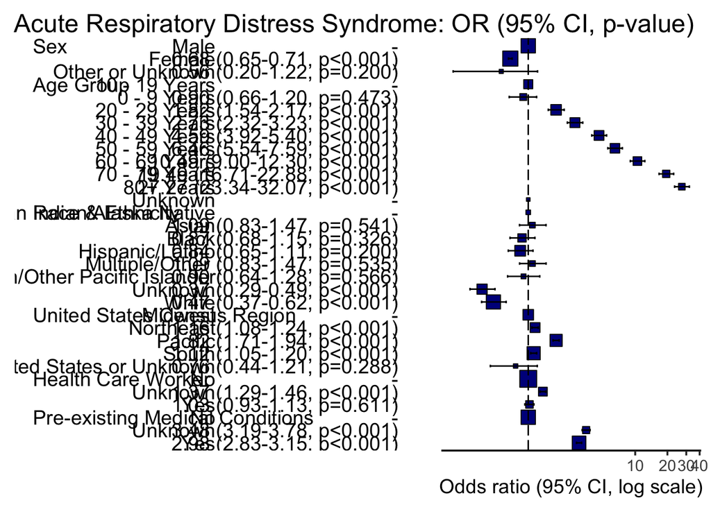

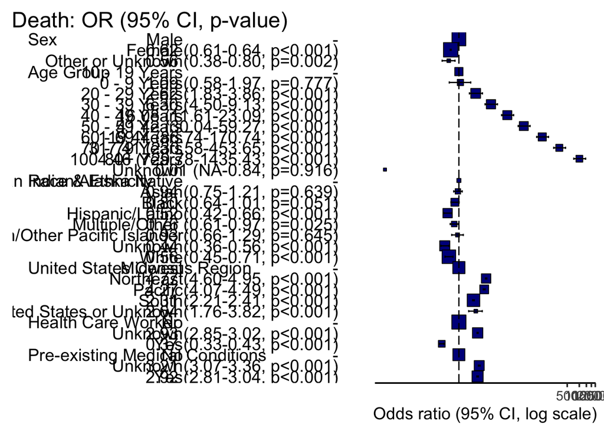

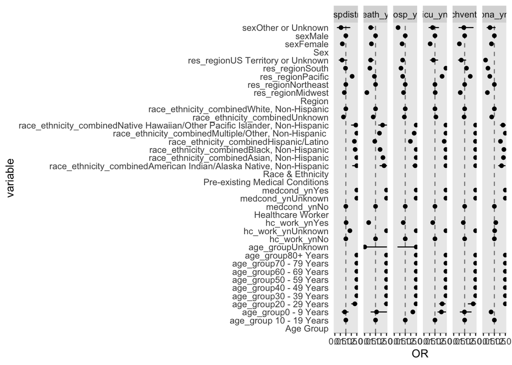

```r
forest <- do.call(dplyr::bind_rows, figure.forest)

ggplot(data=forest, aes(y=variable, x=or, xmin=x2_5_percent, xmax=x97_5_percent)) +
  geom_point() +
  geom_errorbarh(height=.1)+
  scale_x_continuous(limits=c(-0,2), breaks = c(0, 0.5, 1, 1.5, 2), name="OR", oob=scales::squish)  +
  scale_y_discrete(limits = rev(levels(forest$variable))) +
  geom_vline(xintercept=1, color="black", linetype="dashed", alpha=.5) +
  facet_grid(cols = vars(dependent)) +
  theme(
    axis.ticks.y=element_blank(),
    axis.line.x = element_line(color="black", size = 0.1),
    panel.grid.major=element_blank(),
    panel.grid.minor=element_blank(),
    plot.background=element_blank()
    )
```

```r
ggsave("forest_figure.tiff", width = 11, height = 6.5, units = c("in"), dpi = 1200)
```

Time for the chunk ADJUSTED MODEL DEPENDENT to run: 4.01730473975341 hours